# Trabajo Módulo12: Pump it Up Data Mining the Water Table

Diego Maquedano Pedrero

Abril 2022

# 1 Configuración inicial y carga de paquetes

Antes de comenzar con los enunciados y el proyecto en sí, se comprueban si las distintas librerías que van a emplearse están instaladas para, en caso contrario, proceder a ello:

```r
comprobar <- function(pkg){
    new.pkg <- pkg[!(pkg %in% installed.packages()[, "Package"])]
    if (length(new.pkg))
        install.packages(new.pkg, dependencies = TRUE, repos = "http://cran.us.r-project.org")
    sapply(pkg, require, character.only = TRUE)
}
paquetes<-c("e1071","caret","MASS","dummies","naniar",
            "nnet","NeuralNetTools","ggplot2","plotly","dplyr",
            "data.table","reshape","pROC","reshape2","rpart", "rpart.plot",
            "resample","randomForest","rattle","gbm","xgboost","caretEnsemble","parallel","doParallel","visualpred","plyr","arm","ggpubr","data.table","DataExplorer","inspectdf", "zoo", "DescTools","mice", "VIM")

comprobar(paquetes)
```

```
##          e1071          caret           MASS        dummies         naniar
##           TRUE           TRUE           TRUE           TRUE           TRUE
##           nnet NeuralNetTools        ggplot2         plotly          dplyr
##           TRUE           TRUE           TRUE           TRUE           TRUE
##     data.table        reshape           pROC       reshape2          rpart
##           TRUE           TRUE           TRUE           TRUE           TRUE
##     rpart.plot       resample   randomForest         rattle            gbm
##           TRUE           TRUE           TRUE           TRUE           TRUE
##        xgboost  caretEnsemble       parallel     doParallel     visualpred
##           TRUE           TRUE           TRUE           TRUE           TRUE
##           plyr            arm         ggpubr     data.table   DataExplorer
##           TRUE           TRUE           TRUE           TRUE           TRUE
##      inspectdf            zoo      DescTools           mice            VIM
##           TRUE           TRUE           TRUE           TRUE           TRUE
```

Se coloca el código para ejecutar en paralelo y mejorar la velocidad:

```r
cluster <- makeCluster(detectCores() - 1)
registerDoParallel(cluster)
```

También se carga la función customizada multiplot:

```r
source("multiplot.R")
```

# 2 1. Presentación de los datos

## 2.1 1.1 Origen del dataset, descripción del problema y carga de datos

El conjunto de datos sobre el que se va a trabajar consiste en un dataframe con observaciones procedentes del ministerio de Tanzania relativos a una serie de bombas de agua (o pozos) y variables relacionadas con ellos.

Así, el objetivo será intentar predecir en base a estas mismas variables cuál es el estado operativo de cada pozo.

Lo primero que se hará será unir las observaciones y variables independientes con la variable dependiente, pues vienen en archivos separados. También se cargará el test set para unirlo al train y tener toda la información contenida en un único dataframe. Con la finalidad de diferenciarlos en los algoritmos, se añadirá la columna train_test indicando a qué conjunto pertenece cada uno:

```r
train_indep<-read.csv("Train_Data.csv", sep = ",")
train_labels<-read.csv("Train_Labels.csv", sep = ",")

train_set<-merge(x=train_indep, y=train_labels, by="id")
train_set$train_test<-"train"

test_set<-read.csv("Test_data.csv", sep = ",")
test_set$train_test<-"test"

df = bind_rows(train_set,test_set)
```

## 2.2 1.2 Descripción de las variables

En este apartado se indicará el significado de cada una de las variables independientes para hacerse una idea de la información que contiene el dataset:

**amount_tsh**: Cantidad de agua disponible en el pozo

**date_recorded**: Fecha en la que se incluyó el registro

**funder**: Quién financió la construcción pozo

**gps_height**: Altura a la que se encuentra el pozo

**installer**: Quién construyó el pozo

**longitude**: Coordenadas de longitud

**latitude**: Coordenadas de latitud

**wpt_name**: Nombre del pozo

**num_private**: No se indica información sobre esta variable

**basin**: Cuenca hidrográfica

**subvillage**: Aldea

**region**: Región

**region_code**: Código de la región

**district_code**: Código del distrito

**lga**: Localización (1)

**ward**: Localización (2)

**population**: Población alrededor del pozo

**public_meeting**: Si el pozo es público

**recorded_by**: Quién introdujo el registro

**scheme_management**: Quién se encarga del pozo (1)

**scheme_name**: Quién se encarga del pozo (2)

**permit**: Si el pozo está construido legalmente

**construction_year**: Año en que se construyó el pozo

**extraction_type**: Forma en que se extrae el agua del pozo (1)

**extraction_type_group**: Forma en que se extrae el agua del pozo (2)

**extraction_type_class**: Forma en que se extrae el agua del pozo (3)

**management**: Quién se encarga del pozo (3)

**management_group**: Quién se encarga del pozo (4)

**payment**: Forma de pago en la extracción del agua (1)

**payment_type**: Forma de pago en la extracción del agua (1)

**water_quality**: Calidad del agua (1)

**quality_group**: Calidad del agua (2)

**quantity**: Cantidad de agua (1)

**quantity_group**: Cantidad de agua (2)

**source**: Procedencia del agua (1)

**source_type**: Procedencia del agua (2)

**source_class**: Procedencia del agua (3)

**waterpoint_type**: Tipo de pozo (1)

**waterpoint_type_group** Tipo de pozo (2)

Lo primero que llama la atención es que hay bastantes variables muy similares, es decir, que parece que contienen la misma información o muy parecida, como las relacionadas con la localización o la gestión de los pozos. Esto se explorará más en detalle en los próximos apartados de EDA.

```r
str(df)
```

```
## 'data.frame':    74250 obs. of  42 variables:
##  $ id                   : int  0 1 2 3 4 5 6 7 8 9 ...
##  $ amount_tsh           : num  0 0 0 10 0 50 0 0 0 0 ...
##  $ date_recorded        : chr  "2012-11-13" "2011-03-05" "2011-03-27" "2013-06-03" ...
##  $ funder               : chr  "Tasaf" "Shipo" "Lvia" "Germany Republi" ...
##  $ gps_height           : int  0 1978 0 1639 0 28 0 0 0 0 ...
##  $ installer            : chr  "TASAF" "SHIPO" "LVIA" "CES" ...
##  $ longitude            : num  33.1 34.8 36.1 37.1 36.2 ...
##  $ latitude             : num  -5.12 -9.4 -6.28 -3.19 -6.1 ...
##  $ wpt_name             : chr  "Mratibu" "none" "Bombani" "Area 7 Namba 5" ...
##  $ num_private          : int  0 0 0 0 0 0 0 0 0 0 ...
##  $ basin                : chr  "Lake Tanganyika" "Rufiji" "Wami / Ruvu" "Pangani" ...
##  $ subvillage           : chr  "Majengo" "Magoda C" "Songambele" "Urereni" ...
##  $ region               : chr  "Tabora" "Iringa" "Dodoma" "Kilimanjaro" ...
##  $ region_code          : int  14 11 1 3 1 60 17 1 1 18 ...
```

[output cut: 28 more lines]

Todas ellas están codificadas como strings excepto las numéricas que son integer. Es muy posible que muchas de ellas sean categóricas y habrá que convertirlas a factor posteriormente.

En este primer vistazo, se observa por ejemplo que la variable construction_year posee bastantes valores 0, lo que hace suponer que estos puedan ser NA mal codificados y que en el resto del dataset ocurra un problema similar. También se puede ver en las variables payment con la categoría unknown.

## 2.3 1.3 Eliminación y transformación de variables duplicadas.

Dentro del dataframe hay algunas variables que contienen la misma información o muy parecida, de manera que la información que proporcionan es redundante para la creación de los modelos y se puede proceder a su borrado para reducir también el tamaño del dataset. Algunas son las relacionadas con quantity, management, payment, quality, source, extraction y waterpoint_type. Se crea una función que permitirá ir visualizando los valores de estos pares de variables:

```r
repeated_variables<-function(variable_1,variable_2){

    plot_1<-ggplot(data = df, aes(x = {{variable_1}}, y = ..count.., fill = {{variable_1}})) +
      geom_bar() +
      labs(title = "Variable 1") +
      theme_bw() +
      theme(legend.position = "bottom", axis.text.x=element_text(angle=45, hjust=1))

    plot_2<-ggplot(data = df, aes(x = {{variable_2}}, y = ..count.., fill = {{variable_2}})) +
      geom_bar() +
      labs(title = "Variable 2") +
      theme_bw() +
      theme(legend.position = "bottom", axis.text.x=element_text(angle=45, hjust=1))

    ggarrange(plot_1, plot_2,
              ncol = 2, nrow = 1)
}
```

Empezando con payment:

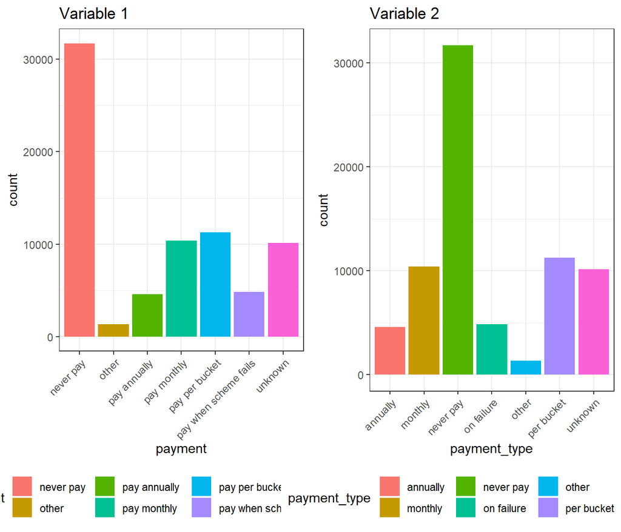

```r
repeated_variables(payment, payment_type)
```

En ambos se muestran las mismas categorías, con la única diferencia de que los nombres son algo más específicos en payment con lo que se eliminará payment_type.

En cuanto a la calidad del agua:

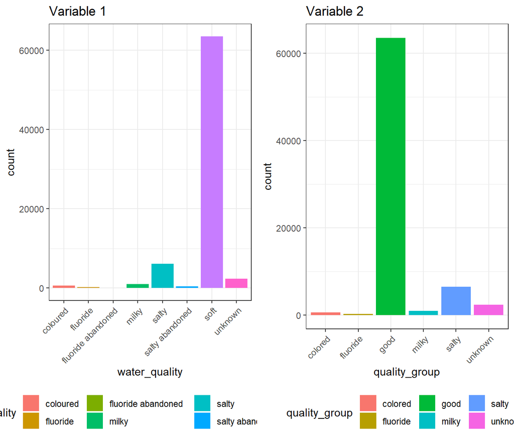

```r
repeated_variables(water_quality, quality_group)
```

La variable water_quality posee mayor especificidad e incluye todos los valores de quality_group, con lo que se eliminará quality_group.

Ahora con management, hay hasta 4 variables que proporcionan información más o menos similar. En primer lugar se atenderá a la información sobre quién se encarga del pozo:

```r
table(df$scheme_management)
```

```
##
##                           Company             None            Other
##             4846             1341                1              996
##       Parastatal Private operator              SWC            Trust
##             2124             1326              123               92
##              VWC  Water authority      Water Board              WUA
##            45917             3975             3462             3551
##              WUG
##             6496
```

```r
length(unique(df$scheme_name))
```

```
## [1] 2869
```

Con estos datos, se ve que scheme_name contiene una cantidad excesiva de niveles y se puede prescindir de ella tomando como variable categórica de referencia para esta información el scheme_management.

El otro par de variables muestra la manera de gestionar el pozo:

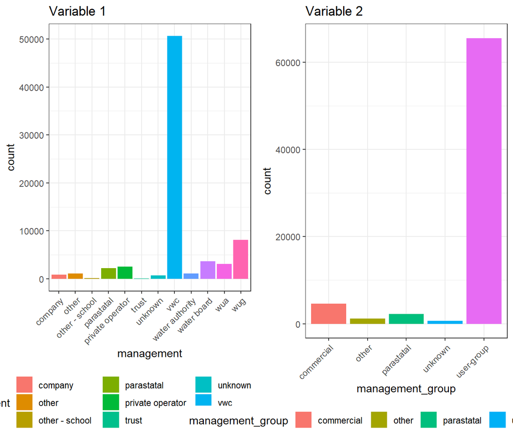

```r
repeated_variables(management, management_group)
```

La información no parece solaparse del todo entre ellas, pero sí entre management y scheme_management, por lo que se eliminará también scheme_management.

Pasando a source:

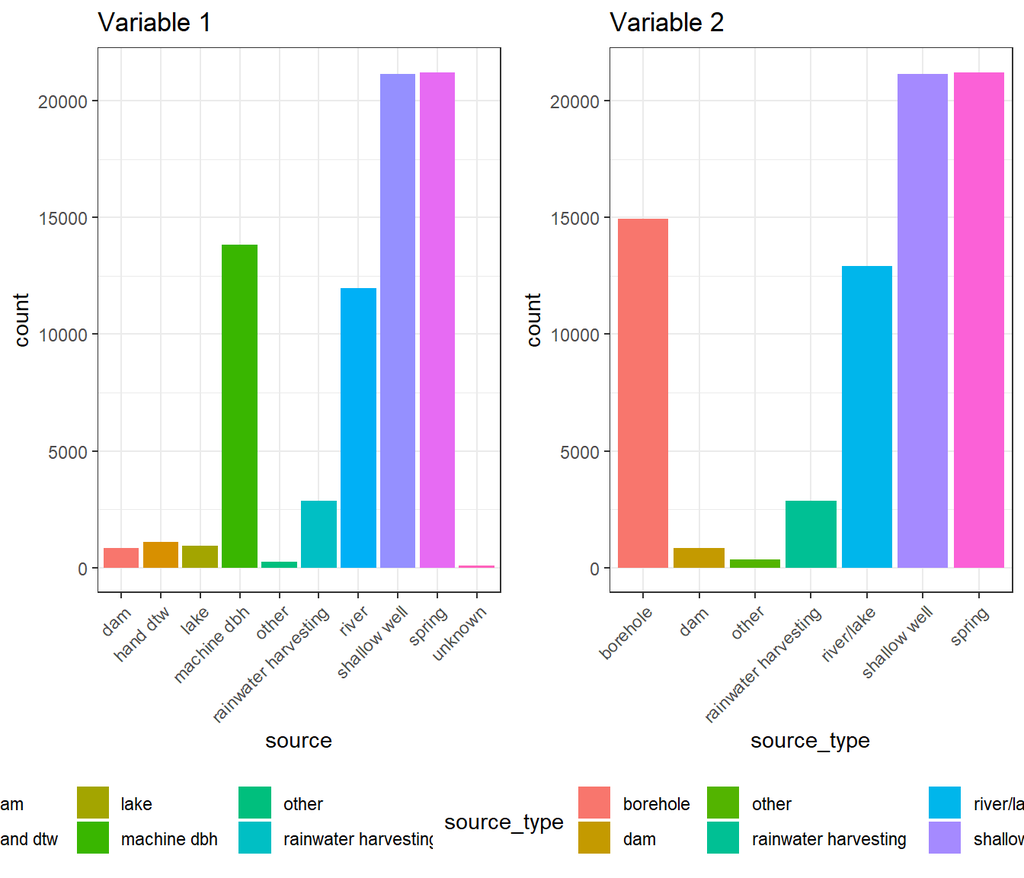

```r
repeated_variables(source, source_type)
```

La variable source aporta mayor especificidad, por lo que es la que se elige para continuar en el dataset.

En cuanto a quantity:

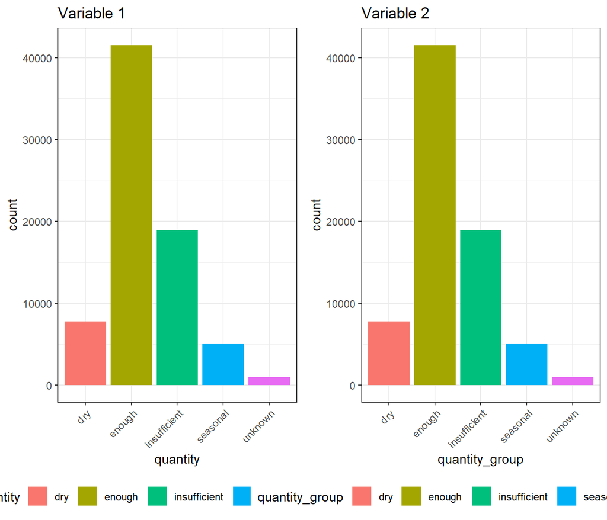

```r
repeated_variables(quantity, quantity_group)
```

Son exactamente iguales, se eliminará quantity_group.

Respecto al tipo de pozo:

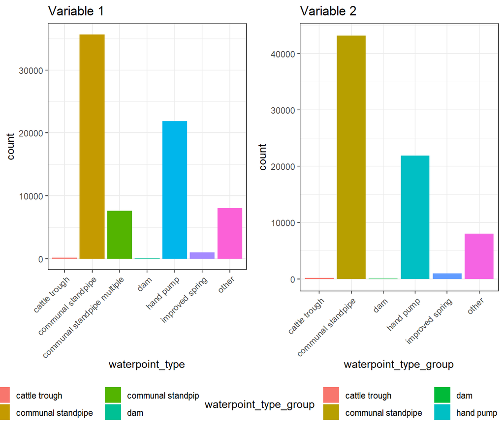

```r
repeated_variables(waterpoint_type,waterpoint_type_group)
```

La última de las variables a considerar en este apartado tiene 3 variaciones y esta es extraction. Hace referencia a la forma en que se puede extraer el agua del pozo por lo que, a continuación, se muestra la interacción entre las 3 columnas de menor a mayor especificidad:

```r
df %>%
    group_by(extraction_type_class,extraction_type_group,extraction_type) %>%
    dplyr::summarise(n=n())
```

```
## # A tibble: 18 x 4
## # Groups:   extraction_type_class, extraction_type_group [13]
##    extraction_type_class extraction_type_group extraction_type               n
##    <chr>                 <chr>                 <chr>                     <int>
##  1 gravity               gravity               gravity                   33263
##  2 handpump              afridev               afridev                    2208
##  3 handpump              india mark ii         india mark ii              3029
##  4 handpump              india mark iii        india mark iii              135
##  5 handpump              nira/tanira           nira/tanira               10205
##  6 handpump              other handpump        other - mkulima/shinyanga     2
##  7 handpump              other handpump        other - play pump           101
##  8 handpump              other handpump        other - swn 81              284
##  9 handpump              other handpump        walimi                       60
## 10 handpump              swn 80                swn 80                     4588
## 11 motorpump             mono                  mono                       3628
## 12 motorpump             other motorpump       cemo                        108
## 13 motorpump             other motorpump       climax                       41
## 14 other                 other                 other                      8102
## 15 rope pump             rope pump             other - rope pump           572
## 16 submersible           submersible           ksb                        1790
## 17 submersible           submersible           submersible                5982
## 18 wind-powered          wind-powered          windmill                    152
```

Viendo el resumen entre las 3 tipologías, las 3 se van a resumir en una única columna que combinará la información de extraction_type_class y extraction_type, puesto que la información de extraction_type_group ya queda recogida por las otras dos.

Se procede a hacer todos los cambios en el dataframe que se han ido mencionando a lo largo del apartado:

```r
df2 <- df %>%
    mutate(extraction = paste0(extraction_type_class, "_", extraction_type)) %>%
    select(-c("payment_type",
              "quality_group",
              "scheme_name",
              "scheme_management",
              "source_type",
              "quantity_group",
              "waterpoint_type_group",
              "extraction_type_class",
              "extraction_type",
              "extraction_type_group"))
```

Se modifican algunos nombres específicos de la columna recién creada:

```r
df2$extraction <- sub("other_other","other",df2$extraction)
df2$extraction <- sub("rope pump_other - rope pump","rope_pump",df2$extraction)
df2$extraction <- sub("submersible_submersible","submersible",df2$extraction)
df2$extraction <- sub("gravity_gravity","gravity",df2$extraction)
```

# 3 2. EDA y feature engineering

Antes que nada se comprobará cuál es la cantidad de NA catalogados como tal dentro del dataset. A ellos habrá que restarles los 14850 presentes en el test_set y que se habrán catalogado como tal al combinarlos con el train_set encontrándose estos en la variable status_group:

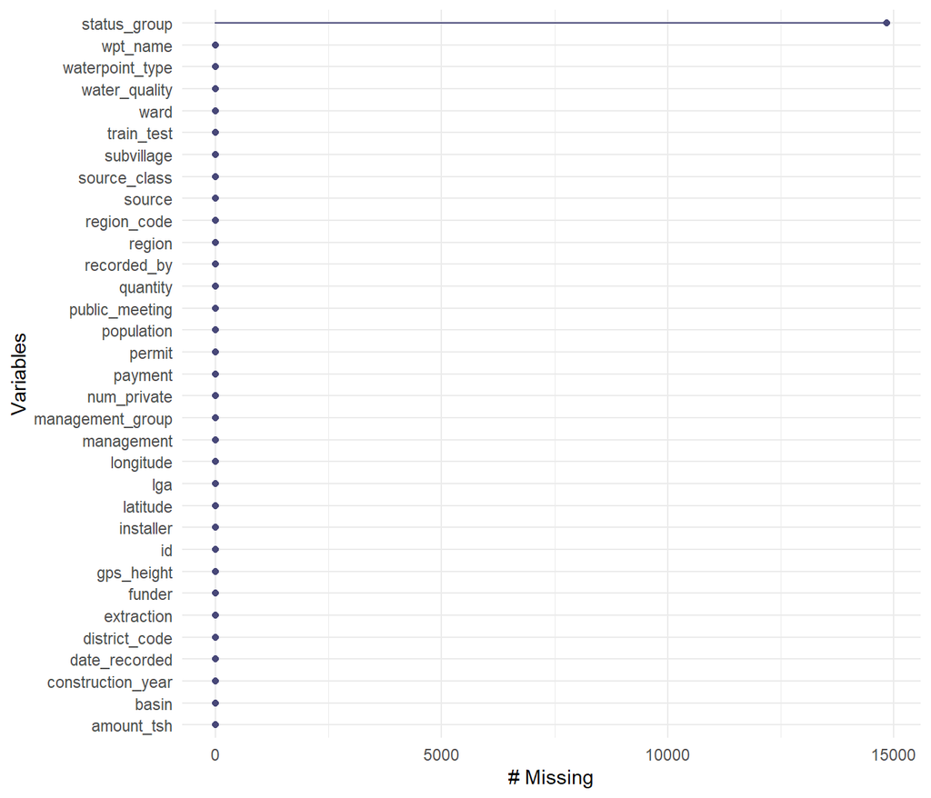

```r
gg_miss_var(df2)
```

Tal como muestra el gráfico, no parece haber ningún valor NA, pero en el análisis preliminar, algunas variables sí daban la impresión de contener este tipo de valores, aunque mal codificados. Por ello, parece que lo primero que ha de hacerse es revisar una a una su contenido y catalogar correctamente los NA así como la correcta tipología de variable.

También antes de continuar se comprueba si hay valores duplicados:

```r
sum(duplicated(df2))
```

```
## [1] 0
```

No hay registros duplicados por lo que el ID podría considerarse como la clave primaria y no hay que eliminar ninguno.

### 3.0.1 amount_tsh (cantidad numérica de agua en el pozo)

La cantidad de agua en los pozos es una de las variables numéricas que, a priori, sí puede ser muy relevante para determinar la variable dependiente. Si se consultan sus posibles valores:

```r
length(unique(df2$amount_tsh))
```

```
## [1] 102
```

Aparecen sólo 102, una cantidad nimia respecto al total de 74250 líneas en el dataset. En cuanto a la frecuencia con la que aparecen cada uno de ellos:

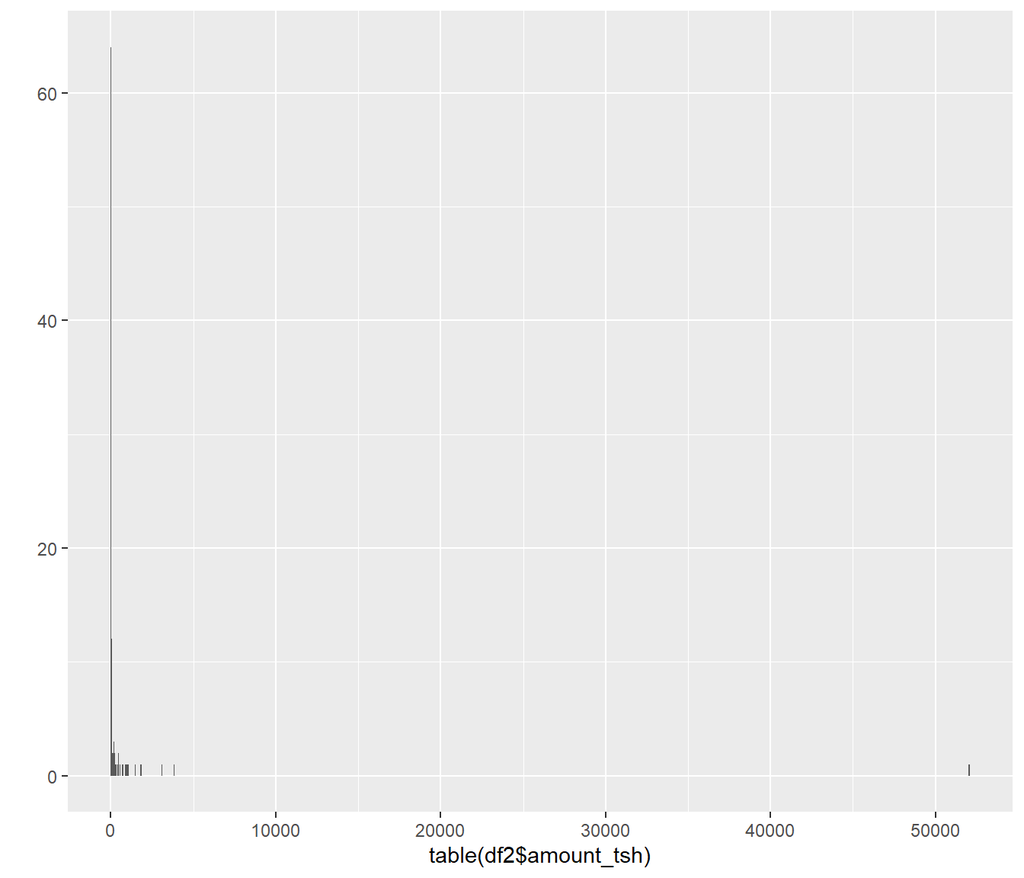

```r
qplot(table(df2$amount_tsh), binwidth=50)
```

Hay una gran cantidad de 0, lo que hace pensar de nuevo que los missing vienen codificados como tal. No obstante, es posible realmente que la cantidad de agua que posean los pozos sea 0, recordando que el clima de Tanzania es realmente caluroso, seco y casi nunca llueve de mayo a octubre como se puede ver en el siguiente enlace https://www.climatestotravel.com/climate/tanzania.

En cuanto a la proporción sobre el total:

```r
df2 %>%
    group_by(amount_tsh) %>%
    tally() %>%
    mutate(proportion = (n / nrow(df))*100) %>% head()
```

```
## # A tibble: 6 x 3
##   amount_tsh     n proportion
##        <dbl> <int>      <dbl>
## 1       0    52049   70.1
## 2       0.2      4    0.00539
## 3       0.25     1    0.00135
## 4       0.5      1    0.00135
## 5       1        3    0.00404
## 6       2       18    0.0242
```

```r
table(df2$quantity)
```

```
##
##          dry       enough insufficient     seasonal      unknown
##         7782        41522        18896         5075          975
```

Aquellos pozos catalogados como dry y cuyo amount_tsh sea 0, se considerarán como observaciones reales, no missing y se comprobará cuál es su proporción después de esta transformación:

```r
df2$amount_tsh <- ifelse(df2$amount_tsh==0 & df2$quantity=="dry", 1, df2$amount_tsh)
df2 %>%
    group_by(amount_tsh) %>%
    tally() %>%
    mutate(proportion = (n / nrow(df))*100) %>% head()
```

```
## # A tibble: 6 x 3
##   amount_tsh     n proportion
##        <dbl> <int>      <dbl>
## 1       0    45166   60.8
## 2       0.2      4    0.00539
## 3       0.25     1    0.00135
## 4       0.5      1    0.00135
## 5       1     6886    9.27
## 6       2       18    0.0242
```

El porcentaje de missing sigue siendo del 61%, con lo que es conveniente eliminar la variable del análisis.

```r
df2 <-df2 %>% select(-amount_tsh)
```

### 3.0.2 date_recorded (Fecha en la que se incluyó el registro)

La variable date_recorded de por sí no aporta mucha información, únicamente indica el momento en que se inscribió la observación en el dataset. Sin embargo, esta variable en combinación con el construction_year puede convertirse en una única que muestre el total de años que lleva el pozo activo en el momento de la creación del dataset restando al año del date_recorded el construction_year:

```r
df2<-df2 %>%
    mutate(operating_years = year(date_recorded) - construction_year)

unique(df2$operating_years)
```

```
##  [1] 2012    3 2011   14    4   29    1   30   12   11    6   36   15 2013   37
## [16]   38   16    7   31   21    8   42   18   10    5   33    2   22   34   28
## [31]   19   25   26    9   39   24   13   23   17   27   51   49   20   41   43
## [46]   35    0   40   48   32   53   45   50   -4   46   52   44   47   -3 2004
## [61]   -1 2002   -5   -7   -2
```

Como se puede ver en los valores únicos de la columna construida, hay algunas cifras que no tienen sentido, como los números negativos o los valores por encima de 2000. Estos se producen en los registros donde el año de construcción está vacío y en algunos errores, pues no puede ser anterior la fecha de registro a la fecha de construcción. Es por ello que estos casos se codificarán como missing y se mostrará el porcentaje que estos representan sobre el total:

```r
df2$operating_years<-ifelse(df2$operating_years < 0 |
                                df2$operating_years > 2000, NA, df2$operating_years)
```

Para ver su frecuencia:

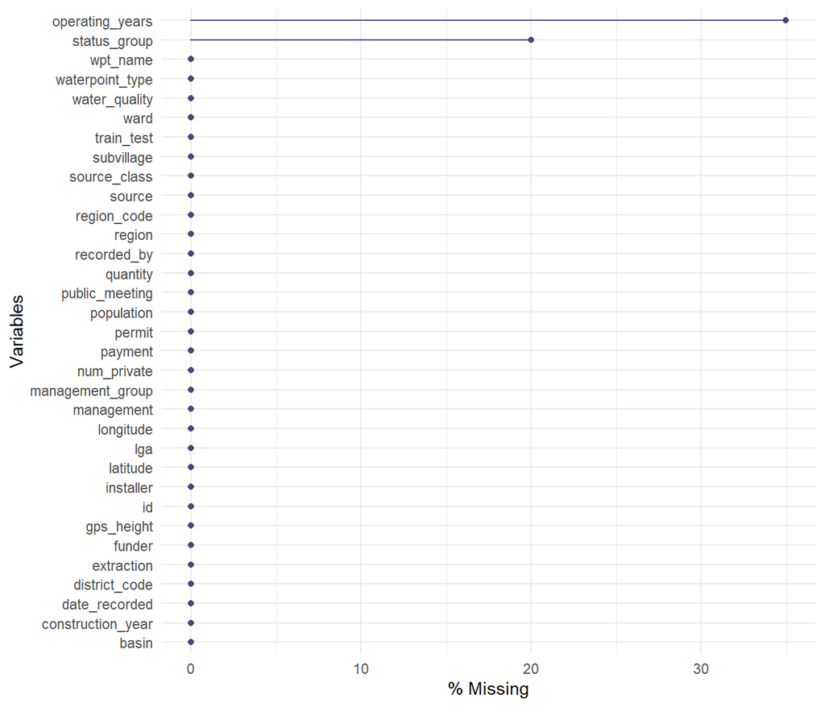

```r
gg_miss_var(df2, show_pct = TRUE)
```

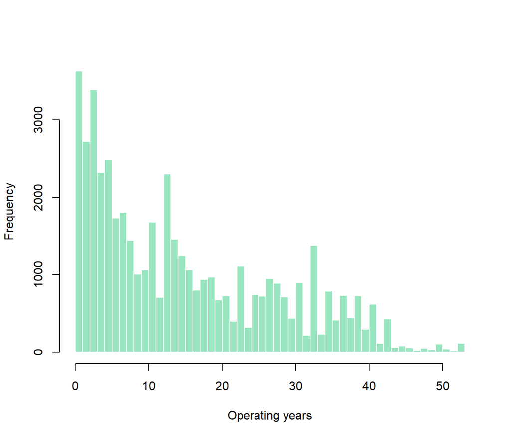

```r
hist(df2$operating_years, breaks=40 , col=rgb(0.2,0.8,0.5,0.5) , border=F , main="" , xlab="Operating years")
```

Y para no imputar con un valor único que sea la media o mediana, se decide seguir esta técnica que conservará la forma de la distribución. Además tras ello se eliminarán las variables date_recorded y construction_year porque ya habría quedado sintetizada la información que estas aportan en una única variable:

```r
df2$operating_years<-na.locf0(df2$operating_years)
df2$operating_years[1]=3

df2<-df2 %>%
    select(-c(date_recorded,construction_year))
```

Para terminar se visualizará la relación entre esta variable y la objetivo:

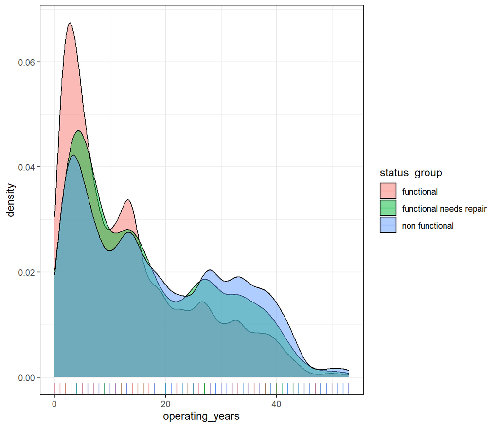

```r
df3<- df2 %>% filter(!is.na(status_group))
ggplot(data = df3, aes(x = operating_years, fill = status_group)) +
      geom_density(alpha = 0.5, na.rm = TRUE) +
      geom_rug(aes(color = status_group), alpha = 0.5) +
      theme_bw()
```

Con el gráfico parece ser claro el deterioro que van sufriendo los pozos con el tiempo porque a mayor valor de los años operativos mayor es las cantidad de pozos con status de no funcional.

Funder es una variable categórica que posee excesivos niveles diferentes:

```r
temp<-Freq(df2$funder)
head(arrange(temp, desc(perc)), 20)
```

```
##                      level    freq   perc  cumfreq  cumperc
## 1   Government Of Tanzania  11'299  15.2%   34'474    46.4%
## 2                            4'504   6.1%    4'504     6.1%
## 3                   Danida   3'907   5.3%   14'881    20.0%
## 4                   Hesawa   2'782   3.7%   38'097    51.3%
## 5                    Rwssp   1'703   2.3%   60'009    80.8%
## 6               World Bank   1'701   2.3%   71'895    96.8%
## 7                     Kkkt   1'623   2.2%   44'276    59.6%
## 8             World Vision   1'562   2.1%   73'459    98.9%
## 9                   Unicef   1'324   1.8%   67'406    90.8%
## 10                   Tasaf   1'136   1.5%   63'806    85.9%
## 11                     Dhv   1'065   1.4%   16'836    22.7%
## 12        District Council   1'037   1.4%   17'966    24.2%
## 13      Private Individual   1'034   1.4%   55'275    74.4%
## 14                    Dwsp   1'012   1.4%   20'083    27.0%
## 15                       0     980   1.3%    5'484     7.4%
## 16                   Norad     949   1.3%   51'924    69.9%
## 17         Germany Republi     765   1.0%   22'879    30.8%
## 18                   Water     739   1.0%   69'336    93.4%
## 19                    Tcrs     735   1.0%   64'755    87.2%
## 20       Ministry Of Water     728   1.0%   48'237    65.0%
```

Se fijará el límite en un mínimo de 700 observaciones, las categorías por debajo de estas se agruparán en la categoría Other con la finalidad de no generar demasiadas variables dummy al pasar a los algoritmos de machine learning:

```r
names_low<-temp %>% filter(freq<700)
names_low<-names_low$level
df2$funder <-ifelse(df2$funder %in% names_low, "Others", df2$funder)
```

Las categorías que son 0 o vacío se calificarán como “Unknown” y se convierte la variable a factor:

```r
df2$funder <-ifelse(df2$funder == "0", "Unknown", df2$funder)
df2$funder <-ifelse(df2$funder == "", "Unknown", df2$funder)
df2$funder<-as.factor(df2$funder)
```

Representando la relación con status_group:

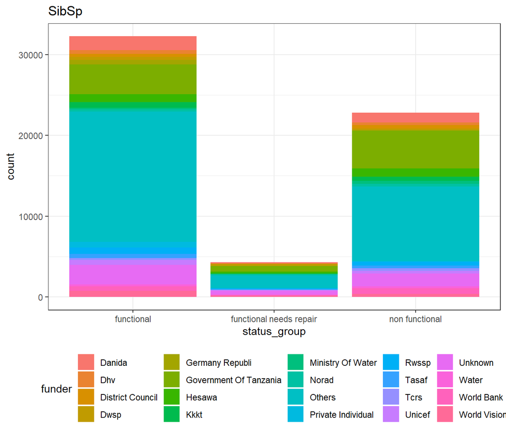

```r
df3<- df2 %>% filter(!is.na(status_group))
ggplot(data = df3, aes(x = status_group, y = ..count.., fill = funder)) +
  geom_bar() +
  labs(title = "SibSp") +
  theme_bw() +
  theme(legend.position = "bottom")
```

En todos los posibles niveles de status_group parece haber la misma proporciónde funders, o lo que es lo mismo, no parece que esta variable sea muy influyente para la situación del pozo.

### 3.0.4 gps_height, latitude y longitude (Medidas de altura, longitud y latitud de los pozos)

Estas 3 variables se analizarán de forma conjunta porque todas permiten representar la localización de los distintos pozos. gps_height es numérica y muestra la altura a la que se encuentra el pozo asumiendo que es sobre el nivel del mar. Los posibles valores que toma son:

```r
Freq(df2$gps_height)
```

```
##                 level    freq   perc  cumfreq  cumperc
## 1            [-200,0]  27'530  37.1%   27'530    37.1%
## 2             (0,200]   4'579   6.2%   32'109    43.2%
## 3           (200,400]   5'861   7.9%   37'970    51.1%
## 4           (400,600]   2'736   3.7%   40'706    54.8%
## 5           (600,800]   2'097   2.8%   42'803    57.6%
## 6         (800,1e+03]   3'447   4.6%   46'250    62.3%
## 7     (1e+03,1.2e+03]   4'866   6.6%   51'116    68.8%
## 8   (1.2e+03,1.4e+03]   7'901  10.6%   59'017    79.5%
## 9   (1.4e+03,1.6e+03]   6'619   8.9%   65'636    88.4%
## 10  (1.6e+03,1.8e+03]   4'979   6.7%   70'615    95.1%
## 11    (1.8e+03,2e+03]   2'113   2.8%   72'728    98.0%
## 12    (2e+03,2.2e+03]   1'163   1.6%   73'891    99.5%
## 13  (2.2e+03,2.4e+03]     293   0.4%   74'184    99.9%
## 14  (2.4e+03,2.6e+03]      58   0.1%   74'242   100.0%
## 15  (2.6e+03,2.8e+03]       8   0.0%   74'250   100.0%
```

Se ve que hay una gran cantidad de valores negativos y 0 que representan hasta el 37% del total. Como es imposible una altura negativa salvo errores y, además, según Wikipedia la altura mínima es el propio Océano Índico https://en.wikipedia.org/wiki/Geography_of_Tanzania se van a considerar estos valores como NA:

```r
df2$gps_height<-ifelse(df2$gps_height <= 0 , NA, df2$gps_height)
```

Antes de hacer nada con ellos se comprobará si realmente son aleatorios o si están relacionados con la localización espacial.

Los valores de longitude son:

```r
Freq(df2$longitude)
```

```
##       level    freq   perc  cumfreq  cumperc
## 1     [0,2]   2'269   3.1%    2'269     3.1%
## 2     (2,4]       0   0.0%    2'269     3.1%
## 3     (4,6]       0   0.0%    2'269     3.1%
## 4     (6,8]       0   0.0%    2'269     3.1%
## 5    (8,10]       0   0.0%    2'269     3.1%
## 6   (10,12]       0   0.0%    2'269     3.1%
## 7   (12,14]       0   0.0%    2'269     3.1%
## 8   (14,16]       0   0.0%    2'269     3.1%
## 9   (16,18]       0   0.0%    2'269     3.1%
## 10  (18,20]       0   0.0%    2'269     3.1%
## 11  (20,22]       0   0.0%    2'269     3.1%
## 12  (22,24]       0   0.0%    2'269     3.1%
## 13  (24,26]       0   0.0%    2'269     3.1%
## 14  (26,28]       0   0.0%    2'269     3.1%
## 15  (28,30]   1'273   1.7%    3'542     4.8%
## 16  (30,32]   8'825  11.9%   12'367    16.7%
## 17  (32,34]  15'288  20.6%   27'655    37.2%
## 18  (34,36]  18'183  24.5%   45'838    61.7%
## 19  (36,38]  16'815  22.6%   62'653    84.4%
## 20  (38,40]  11'196  15.1%   73'849    99.5%
## 21  (40,42]     401   0.5%   74'250   100.0%
```

Hay hasta 2269 valores con longitud 0 y luego ninguno hasta llegar a longitud 28 lo que lleva a pensar que esta segunda es la verdadera mínima longitud y, por tanto, los 0 son NA:

```r
df2$longitude<-ifelse(df2$longitude == 0 , NA, df2$longitude)
```

En cuanto a la latitud:

```r
Freq(df2$latitude)
```

```
##           level   freq   perc  cumfreq  cumperc
## 1   [-12,-11.5]     44   0.1%       44     0.1%
## 2   (-11.5,-11]  1'091   1.5%    1'135     1.5%
## 3   (-11,-10.5]  3'290   4.4%    4'425     6.0%
## 4   (-10.5,-10]  1'980   2.7%    6'405     8.6%
## 5    (-10,-9.5]  2'290   3.1%    8'695    11.7%
## 6     (-9.5,-9]  5'652   7.6%   14'347    19.3%
## 7     (-9,-8.5]  4'381   5.9%   18'728    25.2%
## 8     (-8.5,-8]  2'329   3.1%   21'057    28.4%
## 9     (-8,-7.5]  2'634   3.5%   23'691    31.9%
## 10    (-7.5,-7]  2'168   2.9%   25'859    34.8%
## 11    (-7,-6.5]  3'721   5.0%   29'580    39.8%
## 12    (-6.5,-6]  3'264   4.4%   32'844    44.2%
## 13    (-6,-5.5]  1'823   2.5%   34'667    46.7%
## 14    (-5.5,-5]  2'718   3.7%   37'385    50.4%
## 15    (-5,-4.5]  5'468   7.4%   42'853    57.7%
## 16    (-4.5,-4]  4'584   6.2%   47'437    63.9%
## 17    (-4,-3.5]  4'565   6.1%   52'002    70.0%
## 18    (-3.5,-3]  9'943  13.4%   61'945    83.4%
## 19    (-3,-2.5]  3'764   5.1%   65'709    88.5%
## 20    (-2.5,-2]  1'610   2.2%   67'319    90.7%
## 21    (-2,-1.5]  2'736   3.7%   70'055    94.4%
## 22    (-1.5,-1]  1'918   2.6%   71'973    96.9%
## 23    (-1,-0.5]      8   0.0%   71'981    96.9%
## 24     (-0.5,0]  2'269   3.1%   74'250   100.0%
```

En este caso los valores están algo mejor repartidos que en longitude, pero nos volvemos a encontrar que la latitud con valores entre -0.5 y 0 son 2269, exactamente los mismos casos que longitude y, siendo que la latitud máxima en este país es de -0.99 según http://whereismap.net/where-is-tanzania-what-country-and-continent-is-tanzania/ se pueden considerar estos valores también como NA:

```r
df2$latitude<-ifelse(df2$latitude > -0.5 , NA, df2$latitude)
```

Ahora se intentan representar estas coordenadas a modo de mapa:

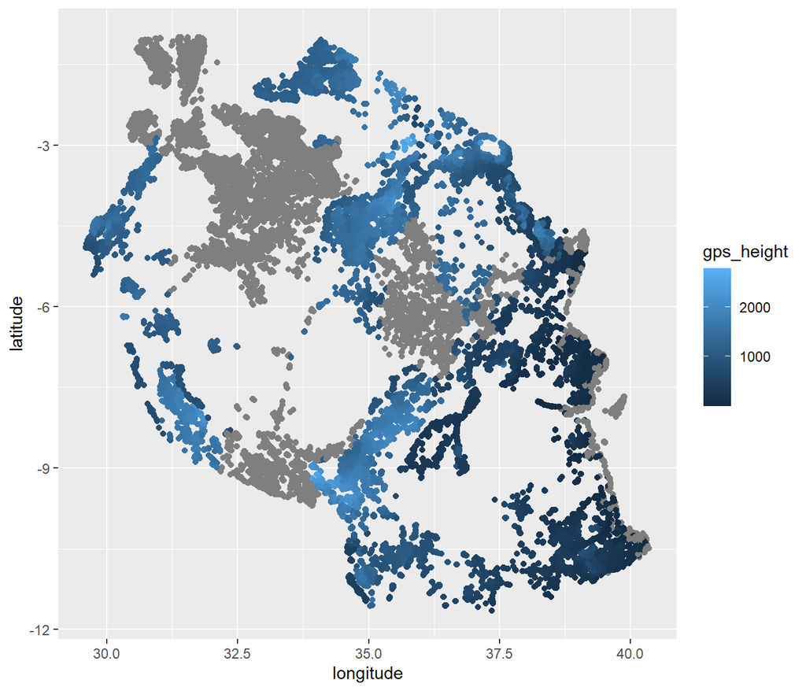

```r
ggplot(df2, aes(x = longitude, y = latitude, color = gps_height))+
    geom_point()
```

Los puntos grises muestran los valores faltantes en la variable gps_height. Se ve claramente que se acumulan en regiones concretas, no son aleatorios y por ello no se van a imputar por el momento.

Para ver la distribución geográfica de los pozos según su estatus:

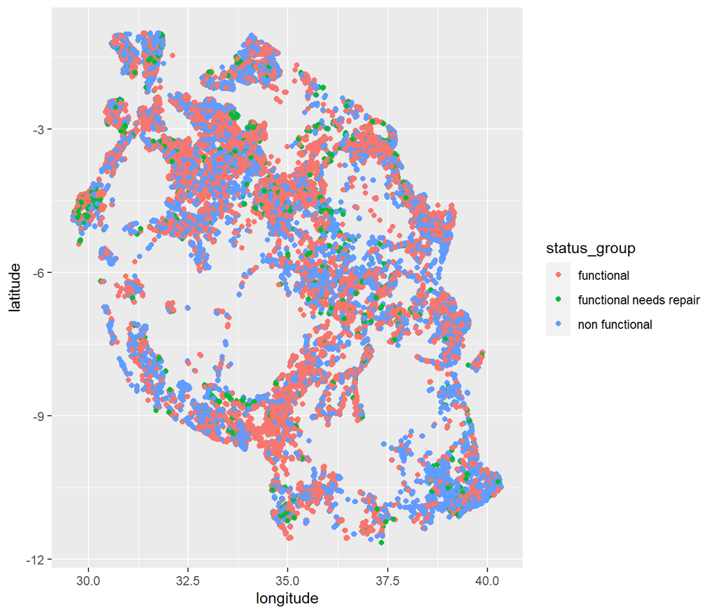

```r
df3 <- df2 %>% filter(!is.na(status_group))
ggplot(df3, aes(x = longitude, y = latitude, color = status_group))+
    geom_point()
```

### 3.0.5 installer (Quién construyó el pozo)

Con esta variable nos encontramos en la misma situación que con funder, una variable categórica con gran cantidad de valores y se procederá de igual forma que antes:

```r
temp<-Freq(df2$installer)
temp %>% dplyr::arrange(desc(perc)) %>% head(20)
```

```
##                  level    freq   perc  cumfreq  cumperc
## 1                  DWE  21'751  29.3%   41'241    55.5%
## 2                        4'532   6.1%    4'532     6.1%
## 3           Government   2'282   3.1%   46'626    62.8%
## 4                  RWE   1'498   2.0%   63'760    85.9%
## 5                Commu   1'347   1.8%   12'333    16.6%
## 6               DANIDA   1'305   1.8%   16'126    21.7%
## 7                 KKKT   1'120   1.5%   53'896    72.6%
## 8               Hesawa   1'070   1.4%   48'881    65.8%
## 9                    0     980   1.3%    5'515     7.4%
## 10                TCRS     887   1.2%   67'881    91.4%
## 11                 CES     765   1.0%   10'447    14.1%
## 12  Central government     764   1.0%    9'356    12.6%
## 13               DANID     690   0.9%   14'820    20.0%
## 14           Community     687   0.9%   13'096    17.6%
## 15              HESAWA     679   0.9%   49'561    66.7%
## 16    District Council     663   0.9%   18'303    24.7%
## 17        World vision     517   0.7%   73'181    98.6%
## 18               TASAF     504   0.7%   66'844    90.0%
## 19                 LGA     501   0.7%   55'568    74.8%
## 20              WEDECO     496   0.7%   72'072    97.1%
```

Las proporciones de lo valores menos frecuentes son similares, así que se fija el límite para considerar un instalador genérico en 700 instalaciones:

```r
names_low<-temp %>% filter(freq<700)
names_low<-names_low$level
df2$installer <-ifelse(df2$installer %in% names_low, "Others", df2$installer)
```

Las categorías que son 0 o vacío se calificarán como NA y se convierte la variable a factor:

```r
df2$installer <-ifelse(df2$installer == "0", NA, df2$installer)
df2$installer <-ifelse(df2$installer == "", NA, df2$installer)
df2$installer<-as.factor(df2$installer)
```

### 3.0.6 wpt_name (Nombre del pozo)

Esta variable que muestra el nombre del pozo sería algo similar al id; pero, a continuación, se muestra que no es un valor único ya que hay un gran número de pozos de nombre “none” o sea que no tienen nombre y otros que se repiten. Debido a la enorme cardinalidad de la misma y a que, por lógica, el nombre del pozo no tiene mucha relevancia en cuanto a su desempeño, ya disponiendo del ID para tal fin, esta variable se eliminará:

```r
temp<-Freq(df2$wpt_name)
temp %>% dplyr::arrange(desc(perc)) %>% head(20)
```

```
##               level   freq  perc  cumfreq  cumperc
## 1              none  4'440  6.0%   59'931    80.7%
## 2           Shuleni  2'183  2.9%   68'729    92.6%
## 3          Zahanati  1'034  1.4%   73'895    99.5%
## 4         Msikitini    647  0.9%   50'872    68.5%
## 5          Kanisani    390  0.5%   10'097    13.6%
## 6            Sokoni    328  0.4%   69'657    93.8%
## 7           Bombani    323  0.4%    2'095     2.8%
## 8           Ofisini    321  0.4%   61'582    82.9%
## 9            School    260  0.4%   64'069    86.3%
## 10  Shule Ya Msingi    247  0.3%   65'464    88.2%
## 11            Shule    191  0.3%   65'170    87.8%
## 12        Sekondari    178  0.2%   64'422    86.8%
## 13         Muungano    159  0.2%   52'124    70.2%
## 14         Mkombozi    145  0.2%   48'726    65.6%
## 15           Upendo    130  0.2%   71'816    96.7%
## 16         Madukani    128  0.2%   44'376    59.8%
## 17   Kituo Cha Afya    113  0.2%   13'008    17.5%
## 18          Mbugani    113  0.2%   47'143    63.5%
## 19            Umoja    105  0.1%   71'605    96.4%
## 20          Mkuyuni    103  0.1%   48'971    66.0%
```

```r
df2<-df2 %>% select(-wpt_name)
```

### 3.0.7 num_private (sin descripción)

Esta variable no posee ninguna descripción, por lo que no se puede interpetar qué tipo de información proporciona:

```r
table(df2$num_private)
```

```
##
##     0     1     2     3     4     5     6     7     8     9    10    11    12
## 73299    94    31    38    30    60    92    31    58     4     5    18     7
##    13    14    15    16    17    20    22    23    24    25    26    27    30
##     1     3    47    13    24    14    11     2     5    14     3     2     1
##    32    34    35    38    39    41    42    45    47    50    55    58    60
##    45    13     1     4    34    12     1    41    27     7     1     4     1
##    61    62    65    80    87    93    94   102   111   120   131   136   141
##     3     1    27    17     1    37     1    28     1     9     1     1     2
##   150   160   180   213   240   280   300   420   450   668   669   672   698
##     6     1     3     1     1     1     1     1     1     1     1     1     1
##   755  1402  1776
##     1     1     1
```

Además, casi todos los posibles valores que toma son 0, con lo que se eliminará del conjunto al no aportar información:

```r
df2<-df2 %>% select(-num_private)
```

### 3.0.8 basin (Cuenca hidrográfica)

La cuenca hidrográfica sí que puede ser un buen indicador para conocer si hay zonas en las que por su localización, el estado de bombeo y la relación con, por ejemplo la cantidad de agua son determinantes:

```r
temp<-Freq(df2$basin)
temp %>% dplyr::arrange(desc(perc)) %>% head(20)
```

```
##                      level    freq   perc  cumfreq  cumperc
## 1            Lake Victoria  12'871  17.3%   39'956    53.8%
## 2                  Pangani  11'143  15.0%   51'099    68.8%
## 3                   Rufiji   9'987  13.5%   61'086    82.3%
## 4                 Internal   9'642  13.0%    9'642    13.0%
## 5          Lake Tanganyika   8'052  10.8%   27'085    36.5%
## 6              Wami / Ruvu   7'577  10.2%   74'250   100.0%
## 7               Lake Nyasa   6'332   8.5%   15'974    21.5%
## 8  Ruvuma / Southern Coast   5'587   7.5%   66'673    89.8%
## 9               Lake Rukwa   3'059   4.1%   19'033    25.6%
```

Visualizándolas en el mapa:

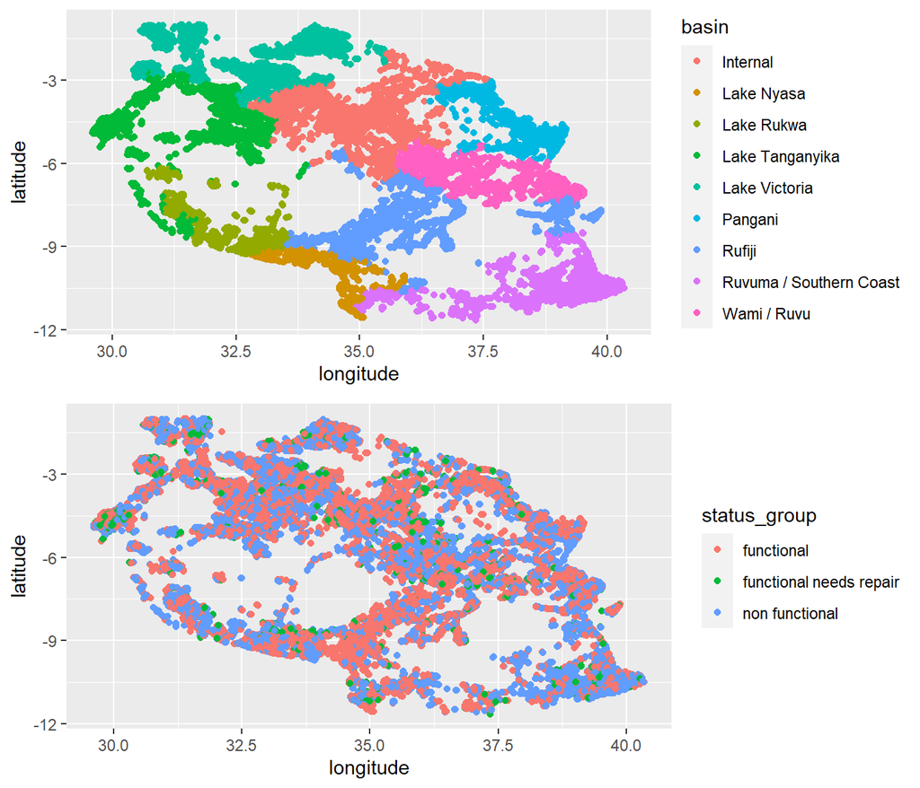

```r
df3 <- df2 %>% filter(!is.na(status_group))
plot_1<-ggplot(df3, aes(x = longitude, y = latitude, color = basin))+
    geom_point()

plot_2<-ggplot(df3, aes(x = longitude, y = latitude, color = status_group))+
    geom_point()

multiplot(plot_1, plot_2)
```

No parece poder extraerse muchas conclusiones debido a la gran cantidad de puntos, pero sí puede verse que hay pocos pozos con estatus de no funcional en la cuenca de Rufiji y Wami, así como mayor concentración de los mismos en la cuenca de Ruvuma. En el resto parecen estar mezclados sin seguir un patrón claro.

La variable no necesita mayores modificaciones más allá de convertirla en factor:

```r
df2$basin <- as.factor(df2$basin)
```

### 3.0.9 subvillage, region, lga, district_code, region_code y ward (Variables geográficas)

Estas variables muestran de nuevo la localización de los pozos con distintos niveles de granuralidad. La manera más precisa de situarlos es mediante las coordenadas de latitud y longitud, pero estas pueden permitir hacer grupos de manera más sencilla. Además, pueden servir para extrapolar y sacar medias de latiud y longitud por distritos e imputar valores a longitud y latitud.

La variable region se puede fijar como categórica, pues tiene una cardinalidad aceptable de 21 niveles:

```r
Freq(df2$region)
```

```
##             level   freq  perc  cumfreq  cumperc
## 1          Arusha  4'111  5.5%    4'111     5.5%
## 2   Dar es Salaam  1'020  1.4%    5'131     6.9%
## 3          Dodoma  2'779  3.7%    7'910    10.7%
## 4          Iringa  6'599  8.9%   14'509    19.5%
## 5          Kagera  4'174  5.6%   18'683    25.2%
## 6          Kigoma  3'533  4.8%   22'216    29.9%
## 7     Kilimanjaro  5'494  7.4%   27'710    37.3%
## 8           Lindi  1'920  2.6%   29'630    39.9%
## 9         Manyara  1'972  2.7%   31'602    42.6%
## 10           Mara  2'451  3.3%   34'053    45.9%
## 11          Mbeya  5'758  7.8%   39'811    53.6%
## 12       Morogoro  5'038  6.8%   44'849    60.4%
## 13         Mtwara  2'144  2.9%   46'993    63.3%
## 14         Mwanza  3'897  5.2%   50'890    68.5%
## 15          Pwani  3'331  4.5%   54'221    73.0%
## 16          Rukwa  2'242  3.0%   56'463    76.0%
## 17         Ruvuma  3'306  4.5%   59'769    80.5%
## 18      Shinyanga  6'293  8.5%   66'062    89.0%
## 19        Singida  2'536  3.4%   68'598    92.4%
## 20         Tabora  2'466  3.3%   71'064    95.7%
## 21          Tanga  3'186  4.3%   74'250   100.0%
```

La distribución del status de los pozos según la región es:

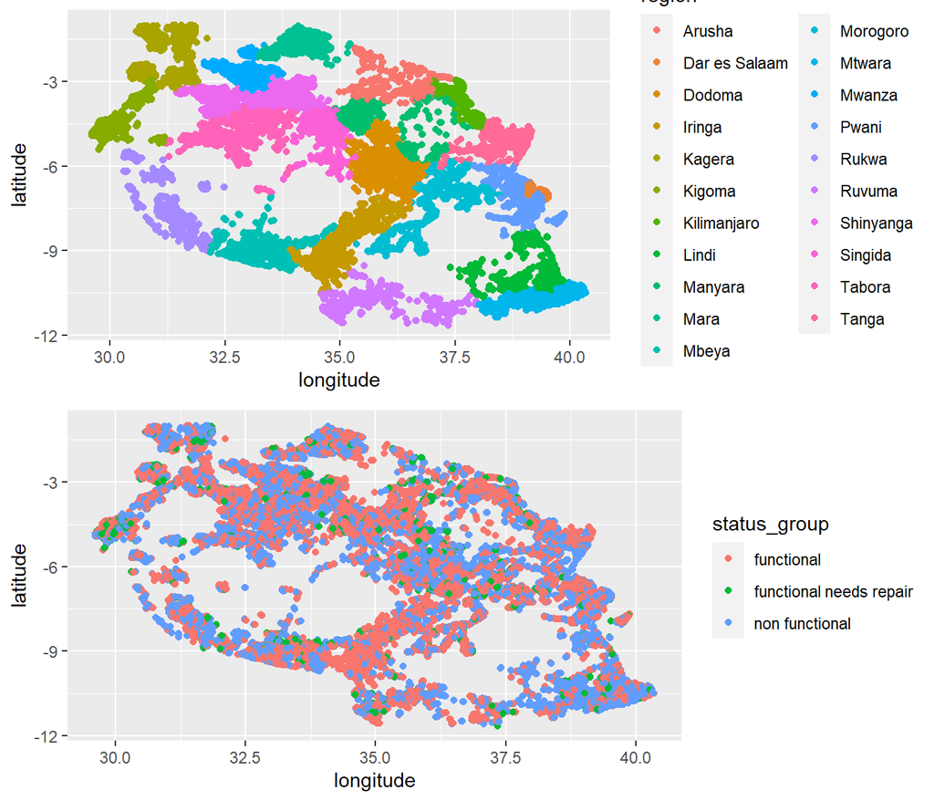

```r
df3 <- df2 %>% filter(!is.na(status_group))
plot_1<-ggplot(df3, aes(x = longitude, y = latitude, color = region))+
    geom_point()

plot_2<-ggplot(df3, aes(x = longitude, y = latitude, color = status_group))+
    geom_point()

multiplot(plot_1, plot_2)
```

La distribución no permite ver una clara tendencia por regiones, parecen distribuirse de forma más o menos homogénea.

También es interesante la información que puede aportar lga, pues algunos nombres contienen el prefijo rural o urban, y, como su cardinalidad es muy alta, se pueden hacer 3 grupos a partir de esta distinción:

```r
df2 = df2 %>% mutate(lga = ifelse( grepl(" rural", lga), "rural",
                                     ifelse( grepl(" urban", lga), "urban","other")))
df2$lga <- as.factor(df2$lga)
df2$region <- as.factor(df2$region)
```

El resto de variables se van a eliminar porque poseen una excesiva cardinalidad y no hay una manera clara de agruparlas, además la información espacial que proporcionan ya se encuentra implícita en longitud y latitud:

```r
df2 = df2 %>% select(-c(region_code,district_code,ward,subvillage))
```

### 3.0.10 population (Población alrededor del pozo)

Esta variable numérica muestra cuál es la población alrededor del pozo. Parece que presenta una gran cantidad de 0:

```r
head(table(df$population))
```

```
##
##     0     1     2     3     4     5
## 26834  8782     9     6    15    50
```

Con hasta 26834 entradas cion ese valor, algo raro teniendo en cuenta que se trata de pozos y su utilidad es servir de agua a la gente. Se visualizan cuáles son estas zonas sin población suponiendo que son valores faltantes:

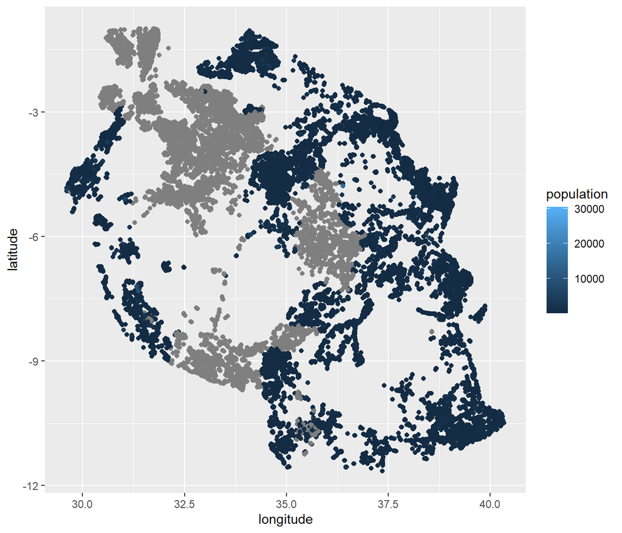

```r
df2$population<-ifelse(df2$population <= 0, NA, df2$population)
df3 <- df2 %>% filter(!is.na(status_group))

ggplot(df3, aes(x = longitude, y = latitude, color = population))+
    geom_point()
```

Las zonas con población 0 parecen coincidir a la perfección con las regiones en las que gps_height es 0 como se analizó previamente:

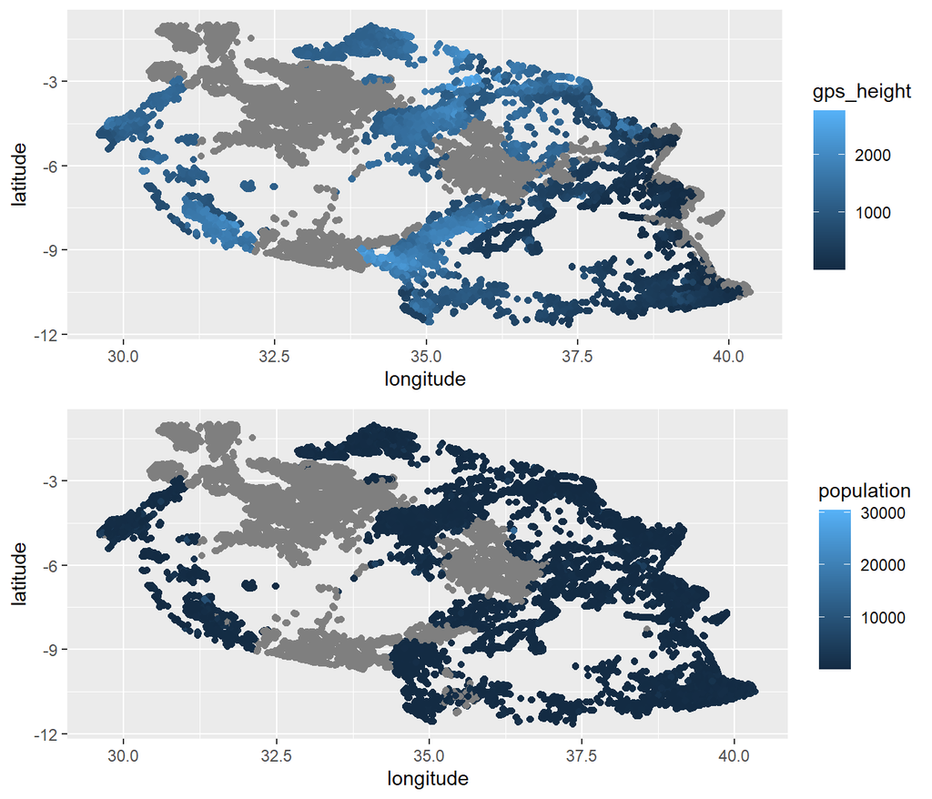

```r
plot_1<-ggplot(df3, aes(x = longitude, y = latitude, color = gps_height))+
    geom_point()

plot_2<-ggplot(df3, aes(x = longitude, y = latitude, color = population))+
    geom_point()

multiplot(plot_1, plot_2)
```

Por lo que en esas zonas puede ser que haya un error en la recogida de datos. Por lo demás no es necesario hacer otras modificaciones.

## 3.1 public_meeting (Si el pozo es público)

Esta es una variable lógica con valores True, Falso y vacíos, que se asumirán missing:

```r
Freq(df2$public_meeting)
```

```
##    level    freq   perc  cumfreq  cumperc
## 1          4'155   5.6%    4'155     5.6%
## 2  False   6'346   8.5%   10'501    14.1%
## 3   True  63'749  85.9%   74'250   100.0%
```

```r
df2$public_meeting<-ifelse(df2$public_meeting <= 0, NA, df2$public_meeting)
df2$public_meeting<-as.factor(df2$public_meeting)
```

### 3.1.1 recorded_by (Quién introdujo el registro)

La variable sólo posee 1 valor que es el mismo para todos los registros. Se elimina del dataset:

```r
df2<-df2 %>% select(-recorded_by)
```

### 3.1.2 management y management_group (Quién se encarga del pozo)

Si se visualizan los valores únicos de estas 2 variables:

```r
Freq(df2$management)
```

```
##                level    freq   perc  cumfreq  cumperc
## 1            company     859   1.2%      859     1.2%
## 2              other   1'083   1.5%    1'942     2.6%
## 3     other - school     126   0.2%    2'068     2.8%
## 4         parastatal   2'229   3.0%    4'297     5.8%
## 5   private operator   2'504   3.4%    6'801     9.2%
## 6              trust     105   0.1%    6'906     9.3%
## 7            unknown     683   0.9%    7'589    10.2%
## 8                vwc  50'624  68.2%   58'213    78.4%
## 9    water authority   1'123   1.5%   59'336    79.9%
## 10       water board   3'688   5.0%   63'024    84.9%
## 11               wua   3'118   4.2%   66'142    89.1%
## 12               wug   8'108  10.9%   74'250   100.0%
```

```r
Freq(df2$management_group)
```

```
##         level    freq   perc  cumfreq  cumperc
## 1  commercial   4'591   6.2%    4'591     6.2%
## 2       other   1'209   1.6%    5'800     7.8%
## 3  parastatal   2'229   3.0%    8'029    10.8%
## 4     unknown     683   0.9%    8'712    11.7%
## 5  user-group  65'538  88.3%   74'250   100.0%
```

Parece claro que management es un desglose con mayor precisión que management_group, concretamente en la categoría de user-group, en la cual no sólo se incluye vwc. Sin embargo, al no tener una alta representación el desglose y generar más cardinalidad que se tendrá que agrupar artificialmente, se decide eliminar management y recategorizar los niveles de management_group distinguiendo entre user-group y others:

```r
df2 <- df2 %>% select(-management)

df2$management_group <-ifelse(df2$management_group != "user-group", "Others", df2$management_group)

df2$management_group<-as.factor(df2$management_group)
```

### 3.1.3 payment (Forma de pago en la extracción del agua)

La variable en principio no necesita ninguna modificación más allá de recategorizar la categoría unknown como Missing y pasar a factor:

```r
Freq(df2$payment)
```

```
##                    level    freq   perc  cumfreq  cumperc
## 1              never pay  31'712  42.7%   31'712    42.7%
## 2                  other   1'314   1.8%   33'026    44.5%
## 3           pay annually   4'570   6.2%   37'596    50.6%
## 4            pay monthly  10'397  14.0%   47'993    64.6%
## 5         pay per bucket  11'266  15.2%   59'259    79.8%
## 6  pay when scheme fails   4'842   6.5%   64'101    86.3%
## 7                unknown  10'149  13.7%   74'250   100.0%
```

```r
df2$payment <-ifelse(df2$payment == "unknown", NA, df2$payment)
df2$payment <- as.factor(df2$payment)
```

### 3.1.4 water_quality (Calidad del agua)

La variable en principio no necesita ninguna modificación más allá de recategorizar la categoría unknown como Missing y pasar a factor:

```r
Freq(df2$water_quality)
```

```
##                 level    freq   perc  cumfreq  cumperc
## 1            coloured     623   0.8%      623     0.8%
## 2            fluoride     244   0.3%      867     1.2%
## 3  fluoride abandoned      23   0.0%      890     1.2%
## 4               milky   1'005   1.4%    1'895     2.6%
## 5               salty   6'082   8.2%    7'977    10.7%
## 6     salty abandoned     423   0.6%    8'400    11.3%
## 7                soft  63'505  85.5%   71'905    96.8%
## 8             unknown   2'345   3.2%   74'250   100.0%
```

```r
df2$water_quality <-ifelse(df2$water_quality == "unknown", NA, df2$water_quality)
df2$water_quality <- as.factor(df2$water_quality)
```

### 3.1.5 quantity (Cantidad de agua)

La variable en principio no necesita ninguna modificación más allá de recategorizar la categoría unknown como Missing y pasar a factor:

```r
Freq(df2$quantity)
```

```
##           level    freq   perc  cumfreq  cumperc
## 1           dry   7'782  10.5%    7'782    10.5%
## 2        enough  41'522  55.9%   49'304    66.4%
## 3  insufficient  18'896  25.4%   68'200    91.9%
## 4      seasonal   5'075   6.8%   73'275    98.7%
## 5       unknown     975   1.3%   74'250   100.0%
```

```r
df2$quantity <-ifelse(df2$quantity == "unknown", NA, df2$quantity)
df2$quantity <- as.factor(df2$quantity)
```

### 3.1.6 source y source_class (Procedencia del agua)

Con estas 2 variables, lo primero que vemos son los niveles que poseen

```r
Freq(df2$source)
```

```
##                    level    freq   perc  cumfreq  cumperc
## 1                    dam     840   1.1%      840     1.1%
## 2               hand dtw   1'108   1.5%    1'948     2.6%
## 3                   lake     950   1.3%    2'898     3.9%
## 4            machine dbh  13'822  18.6%   16'720    22.5%
## 5                  other     261   0.4%   16'981    22.9%
## 6   rainwater harvesting   2'863   3.9%   19'844    26.7%
## 7                  river  11'964  16.1%   31'808    42.8%
## 8           shallow well  21'140  28.5%   52'948    71.3%
## 9                 spring  21'216  28.6%   74'164    99.9%
## 10               unknown      86   0.1%   74'250   100.0%
```

```r
Freq(df2$source_class)
```

```
##          level    freq   perc  cumfreq  cumperc
## 1  groundwater  57'286  77.2%   57'286    77.2%
## 2      surface  16'617  22.4%   73'903    99.5%
## 3      unknown     347   0.5%   74'250   100.0%
```

Se puede ver que source es más específica que source_class, teniendo algunas categorías para nada bien representadas, pero con algunos grupos suficientemente similares. Así, se agruparán todas aquellas categorías por debajo del 10% de representación como “otras” y la categoría unknown se codificará como NA:

```r
temp<-Freq(df2$source)

names_low<-temp %>% filter(perc<0.1)
names_low<-names_low$level
df2$source <-ifelse(df2$source %in% names_low & df2$source != "unknown", "Others", df2$source)

df2$source <-ifelse(df2$source == "unknown", NA, df2$source)
```

Con este mayor nivel de especificidad, pero sin excesiva cardinalidad, se puede prescindir de la otra variable:

```r
df2<-df2 %>% select(-source_class)
```

### 3.1.7 waterpoint_type (Tipo de pozo)

La información que contiene es parecida a la creada artificialmente como extraction, pero no coinciden del todo porque esta muestra el tipo de pozo en sí, mientras que la otra proporciona información acerca de la forma en que se extrae el agua de los mismos. Por ello se sigue conservando y se hará la modificación de combinar las categorías dam, cattle through e improved spring en la misma que other:

```r
Freq(df2$waterpoint_type)
```

```
##                          level    freq   perc  cumfreq  cumperc
## 1                cattle trough     150   0.2%      150     0.2%
## 2           communal standpipe  35'628  48.0%   35'778    48.2%
## 3  communal standpipe multiple   7'611  10.3%   43'389    58.4%
## 4                          dam       8   0.0%   43'397    58.4%
## 5                    hand pump  21'884  29.5%   65'281    87.9%
## 6              improved spring     959   1.3%   66'240    89.2%
## 7                        other   8'010  10.8%   74'250   100.0%
```

```r
names_low<-c("dam","cattle trough","improved spring")
df2$waterpoint_type <-ifelse(df2$waterpoint_type %in% names_low , "other", df2$waterpoint_type)
```

# 4 3. Imputación de valores ausentes, binarización y estandarización

## 4.1 3.1. Imputación Missings

Una vez disponemos del dataset con las variables correctamente colocadas y eliminando las necesarias para llevar a cabo el análisis. Se procederá a imputar los valores ausentes mediante el empleo de distintas librerías.

Lo primero es visualizar después de las transformaciones el total de NA para cada variable:

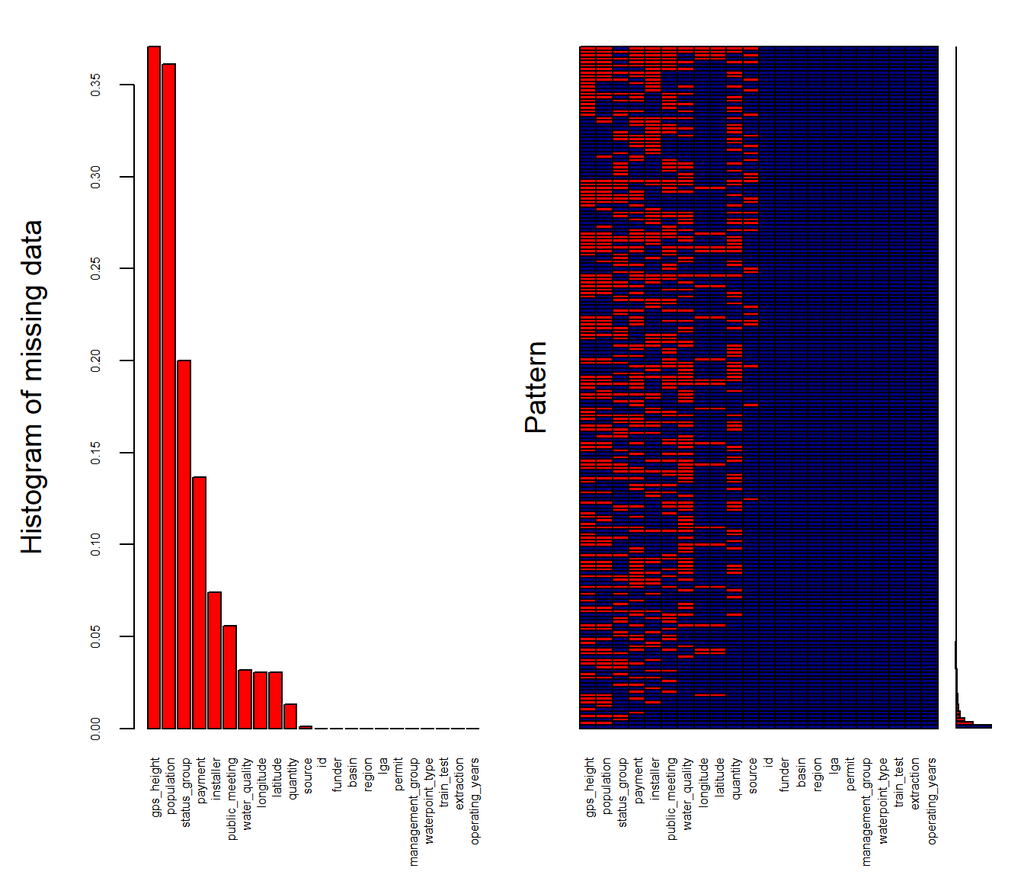

```
##
##  Variables sorted by number of missings:
##          Variable       Count
##        gps_height 0.370774411
##        population 0.361400673
##      status_group 0.200000000
##           payment 0.136686869
##         installer 0.074235690
##    public_meeting 0.055959596
##     water_quality 0.031582492
##         longitude 0.030558923
##          latitude 0.030558923
##          quantity 0.013131313
##            source 0.001158249
##                id 0.000000000
##            funder 0.000000000
##             basin 0.000000000
##            region 0.000000000
##               lga 0.000000000
##            permit 0.000000000
##  management_group 0.000000000
##   waterpoint_type 0.000000000
##        train_test 0.000000000
##        extraction 0.000000000
##   operating_years 0.000000000
```

```r
aggr_plot <-aggr(df2, col = c('navyblue', 'red'),
        numbers = TRUE, sortVars = TRUE, labels = names(df2),
        cex.axis = .5, gap = 3, ylab = c("Histogram of missing data", "Pattern"))
```

Las variables con mayor número de missing son gps_height, population, status_group y payment. status_group obviamente no cuenta porque son los datos del test set que no tienen asignada una calificación.

También se debe tener en cuenta que los datos no son missing at random y que, por este motivo, se deben utilizar otros métodos distintos a la imputación por medias o modas.

Antes de seguir se excluirá la variable status_group (la dependiente) para no realizar imputaciones ni transformaciones, siendo esta después pegada de nuevo al conjunto:

```r
status_col <- df2$status_group
train_test_col<-df2$train_test
df_transformations<- df2 %>% select(-c(status_group,train_test))
```

Se prueba a imputar todas las variables como si fueran MCAR permitiendo que MICE fije el método más adecuado para imputar. El siguiente bloque de código ha sido extraído de RPubs y pertenece a Kazuki Yoshida. Permite especificar las variables a imputar y las que se usarán para realizar la imputación permitiendo paralelización:

```r
## Configure parallelization
## Parallel backend for foreach (also loads foreach and parallel; includes doMC)
library(doParallel)
## Reproducible parallelization
library(doRNG)
## Detect core count
nCores <- min(parallel::detectCores(), 8)
## Used by parallel::mclapply() as default
options(mc.cores = nCores)
## Used by doParallel as default
options(cores = nCores)
## Register doParallel as the parallel backend with foreach
## http://stackoverflow.com/questions/28989855/the-difference-between-domc-and-doparallel-in-r
doParallel::registerDoParallel(cores = nCores)
## Report multicore use
cat("### Using", foreach::getDoParWorkers(), "cores\n")
```

```
## ### Using 8 cores
```

```r
cat("### Using", foreach::getDoParName(), "as backend\n")
```

```
## ### Using doParallelSNOW as backend
```

```r
df_before <- df_transformations

allVars <- names(df_transformations)

missVars <- names(df_transformations)[colSums(is.na(df_transformations)) > 0]

predictorMatrix <- matrix(0, ncol = length(allVars), nrow = length(allVars))
rownames(predictorMatrix) <- allVars
colnames(predictorMatrix) <- allVars


cat("
###  Specify Variables informing imputation\n")
```

```
##
## ###  Specify Variables informing imputation
```

```r
imputerVars <- c("funder","basin","region","lga","permit",
                 "management_group","waterpoint_type","extraction",
                 "operating_years")

imputerVars <- intersect(unique(imputerVars), allVars)
imputerVars
```

```
## [1] "funder"           "basin"            "region"           "lga"
## [5] "permit"           "management_group" "waterpoint_type"  "extraction"
## [9] "operating_years"
```

```r
imputerMatrix <- predictorMatrix
imputerMatrix[,imputerVars] <- 1
imputerMatrix
```

```
##                  id funder gps_height installer longitude latitude basin region
## id                0      1          0         0         0        0     1      1
## funder            0      1          0         0         0        0     1      1
## gps_height        0      1          0         0         0        0     1      1
## installer         0      1          0         0         0        0     1      1
## longitude         0      1          0         0         0        0     1      1
## latitude          0      1          0         0         0        0     1      1
## basin             0      1          0         0         0        0     1      1
## region            0      1          0         0         0        0     1      1
## lga               0      1          0         0         0        0     1      1
## population        0      1          0         0         0        0     1      1
## public_meeting    0      1          0         0         0        0     1      1
## permit            0      1          0         0         0        0     1      1
## management_group  0      1          0         0         0        0     1      1
## payment           0      1          0         0         0        0     1      1
## water_quality     0      1          0         0         0        0     1      1
## quantity          0      1          0         0         0        0     1      1
## source            0      1          0         0         0        0     1      1
## waterpoint_type   0      1          0         0         0        0     1      1
## extraction        0      1          0         0         0        0     1      1
## operating_years   0      1          0         0         0        0     1      1
##                  lga population public_meeting permit management_group payment
## id                 1          0              0      1                1       0
## funder             1          0              0      1                1       0
## gps_height         1          0              0      1                1       0
## installer          1          0              0      1                1       0
## longitude          1          0              0      1                1       0
## latitude           1          0              0      1                1       0
## basin              1          0              0      1                1       0
## region             1          0              0      1                1       0
## lga                1          0              0      1                1       0
## population         1          0              0      1                1       0
## public_meeting     1          0              0      1                1       0
## permit             1          0              0      1                1       0
## management_group   1          0              0      1                1       0
## payment            1          0              0      1                1       0
## water_quality      1          0              0      1                1       0
## quantity           1          0              0      1                1       0
## source             1          0              0      1                1       0
## waterpoint_type    1          0              0      1                1       0
```

[output cut: 29 more lines]

```
## latitude                       1
## basin                          1
## region                         1
## lga                            1
## population                     1
## public_meeting                 1
## permit                         1
## management_group               1
## payment                        1
## water_quality                  1
## quantity                       1
## source                         1
## waterpoint_type                1
## extraction                     1
## operating_years                1
```

```r
cat("
###  Specify variables with missingness to be imputed \n")
```

```
##
## ###  Specify variables with missingness to be imputed
```

```r
imputedOnlyVars <- c("source","payment","installer","public_meeting",
                     "water_quality","longitude","latitude","quantity",
                     "population","gps_height")

imputedVars <- intersect(unique(c(imputedOnlyVars, imputerVars)), missVars)
imputedVars
```

```
##  [1] "source"         "payment"        "installer"      "public_meeting"
##  [5] "water_quality"  "longitude"      "latitude"       "quantity"
##  [9] "population"     "gps_height"
```

```r
imputedMatrix <- predictorMatrix
imputedMatrix[imputedVars,] <- 1
imputedMatrix
```

```
##                  id funder gps_height installer longitude latitude basin region
## id                0      0          0         0         0        0     0      0
## funder            0      0          0         0         0        0     0      0
## gps_height        1      1          1         1         1        1     1      1
## installer         1      1          1         1         1        1     1      1
## longitude         1      1          1         1         1        1     1      1
## latitude          1      1          1         1         1        1     1      1
## basin             0      0          0         0         0        0     0      0
## region            0      0          0         0         0        0     0      0
## lga               0      0          0         0         0        0     0      0
## population        1      1          1         1         1        1     1      1
## public_meeting    1      1          1         1         1        1     1      1
## permit            0      0          0         0         0        0     0      0
## management_group  0      0          0         0         0        0     0      0
## payment           1      1          1         1         1        1     1      1
## water_quality     1      1          1         1         1        1     1      1
## quantity          1      1          1         1         1        1     1      1
## source            1      1          1         1         1        1     1      1
## waterpoint_type   0      0          0         0         0        0     0      0
## extraction        0      0          0         0         0        0     0      0
## operating_years   0      0          0         0         0        0     0      0
##                  lga population public_meeting permit management_group payment
## id                 0          0              0      0                0       0
## funder             0          0              0      0                0       0
## gps_height         1          1              1      1                1       1
## installer          1          1              1      1                1       1
## longitude          1          1              1      1                1       1
## latitude           1          1              1      1                1       1
## basin              0          0              0      0                0       0
## region             0          0              0      0                0       0
## lga                0          0              0      0                0       0
## population         1          1              1      1                1       1
## public_meeting     1          1              1      1                1       1
## permit             0          0              0      0                0       0
## management_group   0          0              0      0                0       0
## payment            1          1              1      1                1       1
## water_quality      1          1              1      1                1       1
## quantity           1          1              1      1                1       1
## source             1          1              1      1                1       1
## waterpoint_type    0          0              0      0                0       0
```

[output cut: 29 more lines]

```
## latitude                       1
## basin                          0
## region                         0
## lga                            0
## population                     1
## public_meeting                 1
## permit                         0
## management_group               0
## payment                        1
## water_quality                  1
## quantity                       1
## source                         1
## waterpoint_type                0
## extraction                     0
## operating_years                0
```

```r
cat("
###  Construct a full predictor matrix (rows: imputed variables; cols: imputer variables)\n")
```

```
##
## ###  Construct a full predictor matrix (rows: imputed variables; cols: imputer variables)
```

```r
predictorMatrix <- imputerMatrix * imputedMatrix
diag(predictorMatrix) <- 0
predictorMatrix
```

```
##                  id funder gps_height installer longitude latitude basin region
## id                0      0          0         0         0        0     0      0
## funder            0      0          0         0         0        0     0      0
## gps_height        0      1          0         0         0        0     1      1
## installer         0      1          0         0         0        0     1      1
## longitude         0      1          0         0         0        0     1      1
## latitude          0      1          0         0         0        0     1      1
## basin             0      0          0         0         0        0     0      0
## region            0      0          0         0         0        0     0      0
## lga               0      0          0         0         0        0     0      0
## population        0      1          0         0         0        0     1      1
## public_meeting    0      1          0         0         0        0     1      1
## permit            0      0          0         0         0        0     0      0
## management_group  0      0          0         0         0        0     0      0
## payment           0      1          0         0         0        0     1      1
## water_quality     0      1          0         0         0        0     1      1
## quantity          0      1          0         0         0        0     1      1
## source            0      1          0         0         0        0     1      1
## waterpoint_type   0      0          0         0         0        0     0      0
## extraction        0      0          0         0         0        0     0      0
## operating_years   0      0          0         0         0        0     0      0
##                  lga population public_meeting permit management_group payment
## id                 0          0              0      0                0       0
## funder             0          0              0      0                0       0
## gps_height         1          0              0      1                1       0
## installer          1          0              0      1                1       0
## longitude          1          0              0      1                1       0
## latitude           1          0              0      1                1       0
## basin              0          0              0      0                0       0
## region             0          0              0      0                0       0
## lga                0          0              0      0                0       0
## population         1          0              0      1                1       0
## public_meeting     1          0              0      1                1       0
## permit             0          0              0      0                0       0
## management_group   0          0              0      0                0       0
## payment            1          0              0      1                1       0
## water_quality      1          0              0      1                1       0
## quantity           1          0              0      1                1       0
## source             1          0              0      1                1       0
## waterpoint_type    0          0              0      0                0       0
```

[output cut: 29 more lines]

```
## latitude                       1
## basin                          0
## region                         0
## lga                            0
## population                     1
## public_meeting                 1
## permit                         0
## management_group               0
## payment                        1
## water_quality                  1
## quantity                       1
## source                         1
## waterpoint_type                0
## extraction                     0
## operating_years                0
```

```r
cat("
###  Dry-run mice for imputation methods\n")
```

```
##
## ###  Dry-run mice for imputation methods
```

```r
dryMice <- mice(data = df_before, m = 1, predictorMatrix = predictorMatrix, maxit = 0)
## Update predictor matrix
predictorMatrix <- dryMice$predictorMatrix
cat("###   Imputers (non-zero columns of predictorMatrix)\n")
```

```
## ###   Imputers (non-zero columns of predictorMatrix)
```

```r
imputerVars <- colnames(predictorMatrix)[colSums(predictorMatrix) > 0]
imputerVars
```

```
## [1] "funder"           "basin"            "region"           "management_group"
## [5] "operating_years"
```

```r
cat("###   Imputed (non-zero rows of predictorMatrix)\n")
```

```
## ###   Imputed (non-zero rows of predictorMatrix)
```

```r
imputedVars <- rownames(predictorMatrix)[rowSums(predictorMatrix) > 0]
imputedVars
```

```
## [1] "gps_height"     "installer"      "longitude"      "latitude"
## [5] "population"     "public_meeting" "payment"        "water_quality"
## [9] "quantity"
```

```r
cat("###   Imputers that are complete\n")
```

```
## ###   Imputers that are complete
```

```r
setdiff(imputerVars, imputedVars)
```

```
## [1] "funder"           "basin"            "region"           "management_group"
## [5] "operating_years"
```

```r
cat("###   Imputers with missingness\n")
```

```
## ###   Imputers with missingness
```

```r
intersect(imputerVars, imputedVars)
```

```
## character(0)
```

```r
cat("###   Imputed-only variables without being imputers\n")
```

```
## ###   Imputed-only variables without being imputers
```

```r
setdiff(imputedVars, imputerVars)
```

```
## [1] "gps_height"     "installer"      "longitude"      "latitude"
## [5] "population"     "public_meeting" "payment"        "water_quality"
## [9] "quantity"
```

```r
cat("###   Variables with missingness that are not imputed\n")
```

```
## ###   Variables with missingness that are not imputed
```

```r
setdiff(missVars, imputedVars)
```

```
## [1] "source"
```

```r
cat("###   Relevant part of predictorMatrix\n")
```

```
## ###   Relevant part of predictorMatrix
```

```r
predictorMatrix[rowSums(predictorMatrix) > 0, colSums(predictorMatrix) > 0]
```

```
##                funder basin region management_group operating_years
## gps_height          1     1      1                1               1
## installer           1     1      1                1               1
## longitude           1     1      1                1               1
## latitude            1     1      1                1               1
## population          1     1      1                1               1
## public_meeting      1     1      1                1               1
## payment             1     1      1                1               1
## water_quality       1     1      1                1               1
## quantity            1     1      1                1               1
```

```r
dryMice$method[setdiff(allVars, imputedVars)] <- ""
cat("###   Methods used for imputation\n")
```

```
## ###   Methods used for imputation
```

```r
dryMice$method[sapply(dryMice$method, nchar) > 0]
```

```
##     gps_height      installer      longitude       latitude     population
##          "pmm"      "polyreg"          "pmm"          "pmm"          "pmm"
## public_meeting        payment  water_quality       quantity
##       "logreg"      "polyreg"      "polyreg"      "polyreg"
```

```r
cat("
###  Run mice\n")
```

```
##
## ###  Run mice
```

```r
M <- 4
cat("### Imputing", M, "times\n")
```

```
## ### Imputing 4 times
```

```r
## Set seed for reproducibility
set.seed(3561126)

## Parallelized execution
miceout <- foreach(i = seq_len(M), .combine = ibind) %dorng% {
    cat("### Started iteration", i, "\n")
    library(mice)
    miceout <- mice(data = df_before, m = 1, print = TRUE,
                    predictorMatrix = predictorMatrix, method = dryMice$method,
                    nnet.MaxNWts = 1000)
    cat("### Completed iteration", i, "\n")
    ## Make sure to return the output
    miceout
}


cat("
###  Show mice results\n")
```

```
##
## ###  Show mice results
```

```r
## mice object ifself
miceout
```

```
## Class: mids
## Number of multiple imputations:  4
## Imputation methods:
##               id           funder       gps_height        installer
##               ""               ""            "pmm"        "polyreg"
##        longitude         latitude            basin           region
##            "pmm"            "pmm"               ""               ""
##              lga       population   public_meeting           permit
##               ""            "pmm"         "logreg"               ""
## management_group          payment    water_quality         quantity
##               ""        "polyreg"        "polyreg"        "polyreg"
##           source  waterpoint_type       extraction  operating_years
##               ""               ""               ""               ""
## PredictorMatrix:
##            id funder gps_height installer longitude latitude basin region lga
## id          0      0          0         0         0        0     0      0   0
## funder      0      0          0         0         0        0     0      0   0
## gps_height  0      1          0         0         0        0     1      1   0
## installer   0      1          0         0         0        0     1      1   0
## longitude   0      1          0         0         0        0     1      1   0
## latitude    0      1          0         0         0        0     1      1   0
##            population public_meeting permit management_group payment
## id                  0              0      0                0       0
## funder              0              0      0                0       0
## gps_height          0              0      0                1       0
## installer           0              0      0                1       0
## longitude           0              0      0                1       0
## latitude            0              0      0                1       0
##            water_quality quantity source waterpoint_type extraction
## id                     0        0      0               0          0
## funder                 0        0      0               0          0
## gps_height             0        0      0               0          0
## installer              0        0      0               0          0
## longitude              0        0      0               0          0
## latitude               0        0      0               0          0
##            operating_years
## id                       0
## funder                   0
## gps_height               1
## installer                1
## longitude                1
## latitude                 1
## Number of logged events:  15
##   it im        dep    meth
## 1  1  1 gps_height     pmm
## 2  1  1  installer polyreg
## 3  1  1 population     pmm
## 4  2  1 gps_height     pmm
## 5  2  1  installer polyreg
## 6  2  1 population     pmm
##                                                                  out
## 1 funderWater, regionDodoma, regionKagera, regionMbeya, regionTabora
## 2                                                regionDar es Salaam
## 3 funderWater, regionDodoma, regionKagera, regionMbeya, regionTabora
## 4 funderWater, regionDodoma, regionKagera, regionMbeya, regionTabora
## 5                                                regionDar es Salaam
## 6 funderWater, regionDodoma, regionKagera, regionMbeya, regionTabora
```

```r
## Variables that no longer have missingness after imputation
cat("###   Variables actually imputed\n")
```

```
## ###   Variables actually imputed
```

```r
actuallyImputedVars <-
    setdiff(names(df_before)[colSums(is.na(df_before)) > 0],
            names(complete(miceout, action = 1))[colSums(is.na(complete(miceout, action = 1))) > 0])
actuallyImputedVars
```

```
## [1] "gps_height"     "installer"      "longitude"      "latitude"
## [5] "population"     "public_meeting" "payment"        "water_quality"
## [9] "quantity"
```

```r
## Examine discrepancies
cat("###   Variables that were unexpectedly imputed\n")
```

```
## ###   Variables that were unexpectedly imputed
```

```r
setdiff(actuallyImputedVars, imputedVars)
```

```
## character(0)
```

```r
cat("###   Variables that were planned for MI but not imputed\n")
```

```
## ###   Variables that were planned for MI but not imputed
```

```r
setdiff(imputedVars, actuallyImputedVars)
```

```
## character(0)
```

```r
## Still missing variables
cat("###   Variables still having missing values\n")
```

```
## ###   Variables still having missing values
```

```r
names(complete(miceout, action = 1))[colSums(is.na(complete(miceout, action = 1))) > 0]
```

```
## [1] "source"
```

Una vez se ha obtenido el resultado, se crea un dataframe en el que se han sustituido los NA:

```r
completedData<-complete(miceout,1)
```

El único que no se ha imputado es source y se le aplicará implicación por moda, pues apenas llega a los 100 valores missing:

```r
val <- unique(completedData$source[!is.na(completedData$source)])
my_mode <- val[which.max(tabulate(match(completedData$source, val)))]
completedData$source[is.na(completedData$source)] <- my_mode
sum(is.na(completedData))
```

```
## [1] 0
```

```r
saveRDS(completedData, "completed_data.rds")
```

Se vuelve a añadir la columna de status_group al dataset:

```r
completedData$status_group <- status_col
completedData$train_test <- train_test_col
```

Y ahora se prosigue con la estandarización.

## 4.2 3.2. Estandarización

La estandarización se aplicará a las variables continuas y se crearán vectores para las continuas, las categóricas y la dependiente:

```r
listconti<-c("gps_height","longitude","latitude","population","operating_years")
listclass<-c("installer", "basin", "region", "lga", "public_meeting", "permit", "management_group", "payment", "water_quality", "quantity", "source", "waterpoint_type","extraction")
vardep<-"status_group"
```

Tras generar los vectores se procede a la estandarización de las variables continuas en torno a la media restando la media y dividiendo entre la desviación típica:

```r
standard_data<-completedData
means <-apply(standard_data[,listconti],2,mean,na.rm=TRUE)
sds<-sapply(standard_data[,listconti],sd,na.rm=TRUE)

df2<-scale(standard_data[,listconti], center = means, scale = sds)

numerocont<-which(colnames(standard_data)%in%listconti)
standard_data<-cbind(df2,standard_data[,-numerocont,drop=FALSE])
```

## 4.3 3.3. Creación de variables dummy

Finalmente, ya se pueden tratar las variables categóricas para pasarlas a dummy:

```r
dfbis<-dummy.data.frame(standard_data, listclass, sep = ".")
str(dfbis)
```

```
## 'data.frame':    74250 obs. of  101 variables:
##  $ gps_height                                   : num  0.417 1.408 0.862 0.826 -0.259 ...
##  $ longitude                                    : num  -0.758 -0.123 0.396 0.794 0.415 ...
##  $ latitude                                     : num  0.244 -1.281 -0.17 0.932 -0.106 ...
##  $ population                                   : num  0.0411 -0.3936 -0.4108 -0.3891 -0.1853 ...
##  $ operating_years                              : num  -0.986 -0.986 -0.986 -0.104 -0.104 ...
##  $ id                                           : int  0 1 2 3 4 5 6 7 8 9 ...
##  $ funder                                       : Factor w/ 20 levels "Danida","Dhv",..: 14 11 11 5 11 11 6 18 18 11 ...
##  $ installer.Central government                 : int  0 0 0 0 0 0 0 0 0 0 ...
##  $ installer.CES                                : int  0 0 0 1 0 0 0 0 0 0 ...
##  $ installer.Commu                              : int  0 0 0 0 0 0 0 0 1 0 ...
##  $ installer.DANIDA                             : int  0 0 0 0 0 0 0 0 0 0 ...
##  $ installer.DWE                                : int  0 0 0 0 0 0 0 0 0 0 ...
##  $ installer.Government                         : int  0 0 0 0 0 0 1 0 0 0 ...
##  $ installer.Hesawa                             : int  0 0 0 0 0 0 0 0 0 0 ...
```

[output cut: 99 more lines]

# 5 4. Modelización

Una vez se tiene el dataframe correctamente preparado, es momento de comenzar a probar distintos modelos. Se comprueba de nuevo cuál es la distribución o la proporción de categorías en la variable dependiente:

```r
Freq(dfbis$status_group)
```

```
##                      level    freq   perc  cumfreq  cumperc
## 1               functional  32'259  54.3%   32'259    54.3%
## 2  functional needs repair   4'317   7.3%   36'576    61.6%
## 3           non functional  22'824  38.4%   59'400   100.0%
```

Ya se explicó previamente que el porcentaje de la categoría “functional needs repair” estaba bastante descompensada, pero al no ser una regresión binaria, no debe ser un problema del todo.

Se probarán distintos algoritmos para extraer las predicciones sobre el test-set.

El primero de ellos será mediante randomForest usando el paquete H2o. Lo primero es inicializar y transformar los dataframes a objetos h2o:

```r
library(h2o)
h2o.init()
```

```
##  Connection successful!
##
## R is connected to the H2O cluster:
##     H2O cluster uptime:         1 hours 9 minutes
##     H2O cluster timezone:       Europe/Paris
##     H2O data parsing timezone:  UTC
##     H2O cluster version:        3.36.0.3
##     H2O cluster version age:    1 month and 9 days
##     H2O cluster name:           H2O_started_from_R_Diego_umn190
##     H2O cluster total nodes:    1
##     H2O cluster total memory:   1.96 GB
##     H2O cluster total cores:    8
##     H2O cluster allowed cores:  8
##     H2O cluster healthy:        TRUE
##     H2O Connection ip:          localhost
##     H2O Connection port:        54321
##     H2O Connection proxy:       NA
##     H2O Internal Security:      FALSE
##     R Version:                  R version 4.1.2 (2021-11-01)
```

A continuación se separan los conjuntos de train y test en base a la columna train_test:

```r
train = dfbis %>%
    filter(train_test == "train") %>% select(-train_test)
test = dfbis %>%
    filter(train_test == "test") %>% select(-c(train_test, status_group))
```

Se establecen las variables predictoras y la objetivo y se convierten los dataframes a objetos H2o:

```r
y <- "status_group"
x <- setdiff(names(train), y)

train_set_h2o = as.h2o(train)
train_set_h2o$status_group<-as.factor(train_set_h2o$status_group)

test_set_h2o = as.h2o(test)
model_rf = h2o.randomForest(
  x = x,
  y = y,
  training_frame = train_set_h2o,
  ntrees = 1000, mtries = 10,
  seed = 123456)
```

Se obtiene también la matriz de confusión con los distintos resultados:

```r
h2o.confusionMatrix(model_rf)
```

```
## Confusion Matrix: Row labels: Actual class; Column labels: Predicted class
##                         functional functional needs repair non functional
## functional                   29831                     347           2081
## functional needs repair       2715                     987            615
## non functional                5961                     201          16662
## Totals                       38507                    1535          19358
##                          Error              Rate
## functional              0.0753 =  2,428 / 32,259
## functional needs repair 0.7714 =   3,330 / 4,317
## non functional          0.2700 =  6,162 / 22,824
## Totals                  0.2007 = 11,920 / 59,400
```

Se hacen las predicciones sobre el test_set y se guardan en csv para enviar a la plataforma de evaluación:

```r
predictions = as.data.frame(h2o.predict(model_rf,test_set_h2o))[,1]
submission = tbl_df(fread("SubmissionFormat.csv")) %>%
  mutate(status_group = predictions)

write.csv(submission, row.names = FALSE, quote = FALSE,
          file = "submission-h2o_randomForest-ntrees1000.csv")
```

La puntuación que se obtiene es de 0.8023 en este intento:

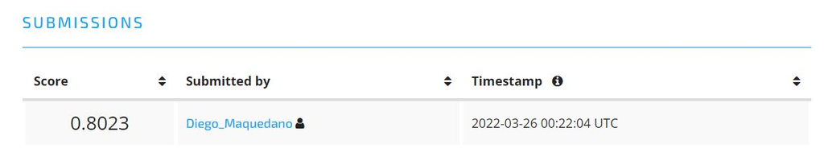

Puntuación 1: Random forest 1000 ntress y 10 mtries

El siguiente algoritmo que se probará es el de redes neuronales utilizando el paquete caret. Para ello se debe hacer una modificación en la variable dependiente que es transformarla en dummy:

```r
train_set_nn<-train_set
listclass_nn<-c(listclass, "status_group")
dfbis_nn<-dummy.data.frame(standard_data, listclass_nn, sep = ".")
dfbis_nn<-dfbis_nn %>% select(-status_group.NA)
```

Hay en torno a 54.000 pozos entre la calificación de funcional y no funcional. Si se estipulan como mínimo 20 observaciones por parámetro en la clase de interés se tienen como máximo 2700 parámetros. Tomando como referencia el total de variables del modelo se tiene que: 2700=h(103+1)+h+1 y el número de nodos resultantes como máximo serían 25

El número de nodos orientativo se obtiene como 2700=h(103+1)+h+1 siendo h=25 y probando con 10, 15 y 20 nodos también.

Y ahora se crea el modelo usando también un grid para extraer el mejor número de nodos y el decay adecuado:

```r
# control<-trainControl(method = "LGOCV",p=0.8,number=1, classProbs=TRUE,savePredictions = "all")
#
# avnnetgrid <-expand.grid(size=c(10,15,20,25),
#                          decay=c(0.01,0.1,0.001), bag=FALSE)
#
# train_nn<-dfbis_nn %>%
#     filter(train_test=="train") %>% select(-train_test)
#
# train_nn$status_group.functional<-as.factor(train_nn$status_group.functional)
# train_nn$`status_group.functional needs repair`<-as.factor(train_nn$`status_group.functional needs repair`)
# train_nn$`status_group.non functional`<-as.factor(train_nn$`status_group.non functional`)
#
# set.seed(77777)
# redavnnet<- train(status_group.functional~.,data=train_nn,
#                   method="avNNet",linout = FALSE,maxit=100,
#                   trControl=control,tuneGrid=avnnetgrid,
#                   repeats=5, verbose=FALSE)
#
# redavnnet
```

Otro de los modelos a probar es la regresión multinomial aplicable cuando la variable respuesta es categórica con más de 2 niveles.

```r
train$status_group<-as.factor(train$status_group)
multinomModel <- multinom(status_group ~ ., data=train)
summary (multinomModel)
```

```
## Call:
## multinom(formula = status_group ~ ., data = train)
##
## Coefficients:
##                         (Intercept)  gps_height  longitude  latitude
## functional needs repair  -0.7897820 -0.01442426 -0.3119591 0.2740309
## non functional            0.2821377 -0.06094584  0.2177345 0.3721935
##                          population operating_years           id  funderDhv
## functional needs repair -0.03237657       0.1403970 2.470568e-06 0.07456593
## non functional          -0.05320820       0.2513018 3.851446e-07 0.04478449
##                         funderDistrict Council funderDwsp funderGermany Republi
## functional needs repair              0.8331309  1.5643057            -0.3186140
## non functional                       0.8283861  0.2921571            -0.5589722
##                         funderGovernment Of Tanzania funderHesawa funderKkkt
## functional needs repair                    0.4706367    1.4901899 -0.9821156
## non functional                             0.7424217    0.5222608  0.7316089
##                         funderMinistry Of Water funderNorad funderOthers
## functional needs repair              0.01640532   0.3857257    0.3883211
## non functional                       0.86964000   0.7001545    0.1094403
##                         funderPrivate Individual funderRwssp funderTasaf
## functional needs repair                0.2187289  0.48617125   0.8240540
## non functional                        -1.1895091 -0.04473046   0.3038713
##                         funderTcrs funderUnicef funderUnknown funderWater
## functional needs repair  0.6278750    0.7444274     0.9493503   1.0952933
## non functional          -0.4130481   -0.1096436    -0.2887467   0.1846151
##                         funderWorld Bank funderWorld Vision
## functional needs repair        0.5588843         1.12333879
## non functional                 0.8435280        -0.04613757
##                         `installer.Central government` installer.CES
## functional needs repair                     -0.1473094    -1.4927603
## non functional                               0.1333053     0.1473591
##                         installer.Commu installer.DANIDA installer.DWE
## functional needs repair       -0.844731       0.04065467    0.03263038
## non functional                -1.234054       0.17241526   -0.18993895
##                         installer.Government installer.Hesawa installer.KKKT
## functional needs repair            0.8682763       -0.9142634      1.6719083
## non functional                     0.2787630       -0.3393303      0.0619308
##                         installer.Others installer.RWE installer.TCRS
## functional needs repair      -0.24470744     0.1786887     0.06183114
## non functional               -0.05933021     0.4498029     0.86121478
```

[output cut: 266 more lines]

```
##                         extraction.motorpump_mono extraction.other
## functional needs repair              2.449057e-13     3.573540e-13
## non functional                       2.598803e-13     4.329261e-13
##                         extraction.rope_pump extraction.submersible
## functional needs repair         3.732816e-14           4.376912e-13
## non functional                  4.685643e-14           5.070996e-13
##                         extraction.submersible_ksb
## functional needs repair               5.694736e-14
## non functional                        1.589778e-13
##                         `extraction.wind-powered_windmill`
## functional needs repair                       1.213626e-14
## non functional                                1.064227e-14
##
## Residual Deviance: 77203.07
## AIC: 77627.07
```

Se obtienen las predicciones y se valida el modelo:

```r
train$ClassPredicted <- predict(multinomModel, newdata = train, "class")
tab <- table(train$status_group, train$ClassPredicted)
round((sum(diag(tab))/sum(tab))*100,2)
```

```
## [1] 72.6
```

Ofrece una precisión del 72.6%, bastante inferior al random forest, pues es un algoritmo menos potente.

Se aplican las predicciones sobre el test set:

```r
test$ClassPredicted <- predict(multinomModel, newdata = test, "class")
```

Se extrae el archivo para subir a la plataforma:

```r
submission = tbl_df(fread("SubmissionFormat.csv")) %>%
  mutate(status_group = test$ClassPredicted)

write.csv(submission, row.names = FALSE, quote = FALSE,
          file = "submission-h2o_multinomModel.csv")
```

En este caso la puntuación obtenida en la plataforma es algo peor, de 0.7245:

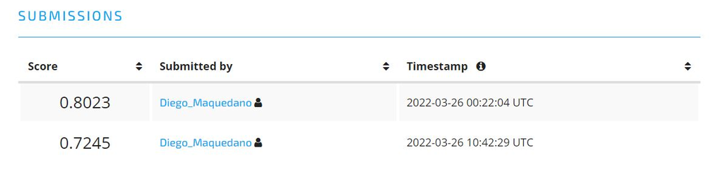

Puntuación 2: Multinomial Regression